# Capstone Modeling

```r
library(tidyverse)
library(caret)
library(DMwR2)
library(e1071)
library(ipred)
library(xgboost)
library(kableExtra)
library(ggthemes)
library(egg)
library(forcats)
library(summarytools)
library(forecast)
library(vtreat)
library(doParallel)
```

# Loading Data

```r
df <- read.csv('modeling_data.csv')
# Identify character columns
char_columns <- sapply(df, is.character)

# Convert character columns to factors
df[char_columns] <- lapply(df[char_columns], as.factor)

glimpse(df)
```

```
## Rows: 1,722
## Columns: 19
## $ rated            <fct> PG-13, PG-13, PG-13, PG-13, PG-13, PG-13, PG, PG-13, …
## $ runtime          <int> 143, 164, 142, 143, 115, 136, 93, 169, 106, 93, 86, 1…
## $ genre            <fct> Action, Action, Action, Action, Adventure, Action, An…
## $ language         <fct> English, English, English, English, English, English,…
## $ country          <fct> United States, United States, United States, United S…
## $ boxoffice        <int> 623357910, 448149584, 408010692, 304360277, 292324737…
## $ budget           <int> 220000000, 250000000, 78000000, 200000000, 120000000,…
## $ num_directors    <int> 1, 1, 1, 1, 1, 1, 3, 1, 1, 3, 2, 1, 1, 2, 1, 1, 1, 2,…
## $ num_actors       <int> 3, 3, 3, 3, 3, 3, 3, 3, 3, 3, 3, 3, 3, 3, 3, 3, 3, 3,…
## $ actor_films5     <int> 17, 17, 7, 12, 17, 8, 4, 0, 12, 10, 3, 11, 7, 5, 12, …
## $ actor_films10    <int> 34, 24, 10, 17, 20, 9, 10, 5, 17, 25, 4, 22, 9, 12, 1…
## $ actor_rev5       <dbl> 1799862677, 1523557430, 438810084, 790069947, 3307645…
## $ actor_rev10      <dbl> 2411207730, 2081390095, 603184119, 1071362460, 337077…
## $ director_films5  <int> 0, 2, 0, 2, 1, 1, 0, 1, 0, 4, 1, 0, 0, 2, 0, 0, 2, 2,…
## $ director_films10 <int> 1, 4, 1, 3, 3, 1, 0, 4, 0, 7, 1, 2, 0, 2, 0, 0, 2, 2,…
## $ director_rev5    <dbl> 0, 827574406, 0, 32363426, 281287133, 32391374, 0, 44…
## $ director_rev10   <dbl> 25514517, 1087527776, 120277854, 95021646, 394908068,…
## $ month            <fct> May, July, March, November, November, July, June, Dec…
## $ bud_avail        <fct> Yes, Yes, Yes, Yes, Yes, Yes, Yes, Yes, Yes, Yes, Yes…
```

We create copies of the dataset to use for each modeling approach,

```r
b.df <- df # data for bagging
r.df <- df # data for random forest
x.df <- df # data for xg boost
c.df <- df # data for cubist
```

# Helper Functions

We use the following helper functions to streamline our processes:

## Calculating Metrics

```r
metrics <- function(predicted, actual){
  results = accuracy(predicted, actual)
  mape = results['Test set','MAPE']
  me = results['Test set','ME']
  mpe = results['Test set','MPE']
  measures = postResample(predicted, actual)
  metrics = c(ME=me, measures, MPE=mpe, MAPE=mape)
  return(metrics)
}
```

## Column IQR Factorizer

Factorizes column by IQR with separate level for NA

```r
# function to create factored column based on IQR plus NA
create_factored_column <- function(column) {
  q <- quantile(column, seq(0, 1, 0.25), na.rm = TRUE)
  factor_column <- cut(column, breaks = q, labels = FALSE, include.lowest = TRUE)
  factor_column[is.na(column)] <- 5  # Assigning 5 for NA
  factor_column <- factor(factor_column, levels = 1:5, labels = c("1", "2", "3", "4", "NA"))
  return(factor_column)
}
```

## Box-Cox Transformer

Box-Cox transforms the response variable.

```r
box.response <- function(df){
  # make a copy of the master dataframe
  t.df <- df

  # Specify the response variable and predictors
  response <- "boxoffice"
  predictors <- names(df)[names(df) != response]

  # Apply Box-Cox transformation only to the response variable
  preprocess.params <- preProcess(df[, response, drop = FALSE], method = "BoxCox")

  # Apply the preProcess function to the response variable
  transformed.response <- predict(preprocess.params, newdata = df[, response, drop = FALSE])

  # Store the transformed response in the boxoffice column
  t.df['boxoffice'] <- transformed.response

  return(t.df)
}
```

## Generating Dummies

Creates dummy variables for categorical predictors.

```r
generate.dummies <- function(df){
  # get names of categorical variables
  cols <- names(df)[sapply(df, is.factor)]

  # One-hot encode factor columns
  dummies <- model.matrix(~.-1, data = df[, cols])

  # combine dummies with numerical columns
  df.encoded <- cbind(df[, !names(df) %in% cols], dummies)

  return(df.encoded)
}
```

## Data Splitting

```r
data.splitter <- function(df) {
  set.seed(1)

  # Shuffle the dataset
  shuffled <- df[sample(nrow(df)), ]

  # Create split point
  split.index <- createDataPartition(df$boxoffice, p = 0.8, list = FALSE)

  # Split the data
  train.set <- shuffled[split.index, ]
  test.set <- shuffled[-split.index, ]

  # Print the code
  cat(sprintf("Training set contains %d rows.", dim(train.set)[1]),
      sprintf("\nTesting set contains %d rows.", dim(test.set)[1]))

  # Return the processed data
  return(list(train.set = train.set, test.set = test.set))
}
```

## Bagged Modeling

```r
bag.deploy <- function(df){
  set.seed(1)

  # split data
  split.data <- data.splitter(df)
  train.set <- split.data$train.set
  test.set <- split.data$test.set

  # enable clusters for parallel processing
  cl <- makeCluster(4)
  registerDoParallel(cl)

  start <- Sys.time()

  model <- train(
    boxoffice ~ .,
    data = train.set,
    method = "treebag",
    trControl = bag.ctrl,
    tuneLength = 10
  )

  end <- Sys.time()

  elapsed.time <- as.numeric(difftime(end, start, units = "secs"))

  preds <- predict(model, test.set)
  results <- metrics(preds, test.set$boxoffice)
  results['TIME'] <- elapsed.time

  stopCluster(cl)

  return(list(model = model, results = results))
}
```

## Random Forest Modeling

```r
rf.deploy <- function(df){

  set.seed(1)

  # split data
  split.data <- data.splitter(df)
  train.set <- split.data$train.set
  test.set <- split.data$test.set

  # enable clusters for parallel processing
  cl <- makeCluster(4)
  registerDoParallel(cl)

  start <- Sys.time()

  model <- train(
    boxoffice ~ .,
    data = train.set,
    method = "rf",
    ntrees = 1000,
    trControl = rf.ctrl,
    parallel = "multicore"
  )

  end <- Sys.time()

  elapsed.time <- as.numeric(difftime(end, start, units = "secs"))

  preds <- predict(model, test.set)
  results <- metrics(preds, test.set$boxoffice)
  results['TIME'] <- elapsed.time

  stopCluster(cl)

  return(list(model = model, results = results))
}
```

## XGBoost Modeling

```r
xg.deploy <- function(df, ctrl, grid, scale=NULL){

  set.seed(1)

  # split data
  split.data <- data.splitter(df)
  train.set <- split.data$train.set
  test.set <- split.data$test.set

  # enable clusters for parallel processing
  cl <- makeCluster(4)
  registerDoParallel(cl)

  start <- Sys.time()

  if (missing(scale)){
    model <- train(
    boxoffice ~ .,
    data = train.set,
    method = "xgbTree",
    trControl = ctrl,
    tuneGrid = grid
    )
  } else {
    model <- train(
    boxoffice ~ .,
    data = train.set,
    method = "xgbTree",
    trControl = ctrl,
    tuneGrid = grid,
    preProc = c(scale)
    )
  }

  end <- Sys.time()

  elapsed.time <- as.numeric(difftime(end, start, units = "secs"))

  preds <- predict(model, test.set)
  results <- metrics(preds, test.set$boxoffice)
  results['TIME'] <- elapsed.time

  stopCluster(cl)

  return(list(model = model, results = results))
}
```

## Cubist Modeling

```r
cube.deploy <- function(df, ctrl, grid, scale=NULL){

  set.seed(1)

  # split data
  split.data <- data.splitter(df)
  train.set <- split.data$train.set
  test.set <- split.data$test.set

  # enable clusters for parallel processing
  cl <- makeCluster(4)
  registerDoParallel(cl)

  start <- Sys.time()

  if (missing(scale)){
    model <- train(
    boxoffice ~ .,
    data = train.set,
    method = "cubist",
    trControl = ctrl,
    tuneGrid = grid
    )
  } else {
    model <- train(
    boxoffice ~ .,
    data = train.set,
    method = "cubist",
    trControl = ctrl,
    tuneGrid = grid,
    preProc = c(scale)
    )
  }

  end <- Sys.time()

  elapsed.time <- as.numeric(difftime(end, start, units = "secs"))

  preds <- predict(model, test.set)
  results <- metrics(preds, test.set$boxoffice)
  results['TIME'] <- elapsed.time

  stopCluster(cl)

  return(list(model = model, results = results))
}
```

## Variable Importance Plotting

```r
plotImp <- function(imp, top_n, title=NULL){

  # Select the top n most important variables
  top_vars <- imp$importance |>
    as.data.frame() |>
    arrange(desc(Overall)) |>
    head(top_n)

    if (missing(title)){
      # Create a horizontal bar plot
      ggplot(top_vars, aes(x = Overall, y = reorder(rownames(top_vars), Overall))) +
        geom_col(fill="lightblue") +
        labs(title = "Most Important Variables",
             x = "Importance",
             y = "Variable") +
        theme_few() +
        theme(plot.title = element_text(hjust = 0.5))
    } else {
      # Create a horizontal bar plot
      ggplot(top_vars, aes(x = Overall, y = reorder(rownames(top_vars), Overall))) +
        geom_col(fill="lightblue") +
        labs(title = title,
             x = "",
             y = "") +
        theme_few() +
        theme(plot.title = element_text(hjust = 0.5,
                                        size = 10))
    }
}
```

## Variable Importance Table

```r
tableImp <- function(imp, top_n){
  imp$importance |>
  arrange(desc(Overall)) |>
  head(top_n) |>
  kable() |> kable_styling()
}
```

# Modeling

## Bagged Trees

We define the parameters for model training, enabling 10-fold cross-validation.

```r
bag.ctrl <- trainControl(
  method = "cv",
  number = 10,
  allowParallel = TRUE
)
```

We perform the BoxCox transformation on the response variable,

```r
b.df <- box.response(b.df)
```

### Baseline Model

First we build a model including no star power variables and imputing zeros for NAs in Budget.

```r
b.base <- b.df |>
  select(c(1:7,18:19)) |>
  mutate(budget = ifelse(is.na(budget),
                         0,
                         budget))

bag.base <- bag.deploy(b.base)
```

```
## Training set contains 1378 rows.
## Testing set contains 344 rows.
```

```r
stack.results <- rbind("bag.baseline" = bag.base$results)
stack.results
```

```
##                      ME     RMSE  Rsquared       MAE       MPE     MAPE
## bag.baseline -0.0935848 1.084371 0.6040531 0.8695907 -1.057409 5.428965
##                  TIME
## bag.baseline 18.72908
```

### V1

- Full dataset.
- Imputing zeros for NAs in Budget.

```r
b.df1 <- b.df |>
  mutate(budget = ifelse(is.na(budget),
                         0,
                         budget))

bag1 <- bag.deploy(b.df1)
```

```
## Training set contains 1378 rows.
## Testing set contains 344 rows.
```

```r
stack.results <- rbind(stack.results, "bag1" = bag1$results)
stack.results
```

```
##                       ME     RMSE  Rsquared       MAE       MPE     MAPE
## bag.baseline -0.09358480 1.084371 0.6040531 0.8695907 -1.057409 5.428965
## bag1         -0.09099274 1.062611 0.6193303 0.8592402 -1.015751 5.353042
##                  TIME
## bag.baseline 18.72908
## bag1         19.96190
```

### V2

- Full dataset.
- Discretizing `budget` variable by IQR.

```r
b.df2 <- b.df |>
  mutate(budget = create_factored_column(budget))

bag2 <- bag.deploy(b.df2)
```

```
## Training set contains 1378 rows.
## Testing set contains 344 rows.
```

```r
stack.results <- rbind(stack.results, "bag2" = bag2$results)
stack.results
```

```
##                       ME     RMSE  Rsquared       MAE       MPE     MAPE
## bag.baseline -0.09358480 1.084371 0.6040531 0.8695907 -1.057409 5.428965
## bag1         -0.09099274 1.062611 0.6193303 0.8592402 -1.015751 5.353042
## bag2         -0.09093805 1.065737 0.6172368 0.8764869 -1.016833 5.439538
##                  TIME
## bag.baseline 18.72908
## bag1         19.96190
## bag2         18.32149
```

### V3

- Remove Near Zero Variance variables
- Impute Zero for NAs.

```r
nzv <- nearZeroVar(b.df, saveMetrics = TRUE, names = TRUE)
nzv |> filter(nzv == TRUE) |> rownames()
```

```
## [1] "language"   "num_actors"
```

```r
cols <- nzv |>
  filter(nzv == TRUE) |>
  rownames()

b.df3 <- b.df1 |>
  select(-cols)

bag3 <- bag.deploy(b.df3)
```

```
## Training set contains 1378 rows.
## Testing set contains 344 rows.
```

```r
stack.results <- rbind(stack.results, "bag3" = bag3$results)
stack.results
```

```
##                       ME     RMSE  Rsquared       MAE       MPE     MAPE
## bag.baseline -0.09358480 1.084371 0.6040531 0.8695907 -1.057409 5.428965
## bag1         -0.09099274 1.062611 0.6193303 0.8592402 -1.015751 5.353042
## bag2         -0.09093805 1.065737 0.6172368 0.8764869 -1.016833 5.439538
## bag3         -0.09099274 1.062611 0.6193303 0.8592402 -1.015751 5.353042
##                  TIME
## bag.baseline 18.72908
## bag1         19.96190
## bag2         18.32149
## bag3         19.38999
```

### V4

- Including only 5-year Star Power

```r
b.df4 <- b.df3 |>
  select(-c(num_directors,
            actor_films10,
            actor_rev10,
            director_films10,
            director_rev10))

bag4 <- bag.deploy(b.df4)
```

```
## Training set contains 1378 rows.
## Testing set contains 344 rows.
```

```r
stack.results <- rbind(stack.results, "bag4" = bag4$results)
stack.results
```

```
##                       ME     RMSE  Rsquared       MAE       MPE     MAPE
## bag.baseline -0.09358480 1.084371 0.6040531 0.8695907 -1.057409 5.428965
## bag1         -0.09099274 1.062611 0.6193303 0.8592402 -1.015751 5.353042
## bag2         -0.09093805 1.065737 0.6172368 0.8764869 -1.016833 5.439538
## bag3         -0.09099274 1.062611 0.6193303 0.8592402 -1.015751 5.353042
## bag4         -0.08998240 1.064850 0.6175457 0.8607279 -1.010223 5.363212
##                  TIME
## bag.baseline 18.72908
## bag1         19.96190
## bag2         18.32149
## bag3         19.38999
## bag4         17.60555
```

### V5

- Including only 10-year Star Power

```r
b.df5 <- b.df3 |>
  select(-c(num_directors,
            actor_films5,
            actor_rev5,
            director_films5,
            director_rev5))

bag5 <- bag.deploy(b.df5)
```

```
## Training set contains 1378 rows.
## Testing set contains 344 rows.
```

```r
stack.results <- rbind(stack.results, "bag5" = bag5$results)
stack.results
```

```
##                       ME     RMSE  Rsquared       MAE       MPE     MAPE
## bag.baseline -0.09358480 1.084371 0.6040531 0.8695907 -1.057409 5.428965
## bag1         -0.09099274 1.062611 0.6193303 0.8592402 -1.015751 5.353042
## bag2         -0.09093805 1.065737 0.6172368 0.8764869 -1.016833 5.439538
## bag3         -0.09099274 1.062611 0.6193303 0.8592402 -1.015751 5.353042
## bag4         -0.08998240 1.064850 0.6175457 0.8607279 -1.010223 5.363212
## bag5         -0.08916172 1.057499 0.6237698 0.8555682 -1.010743 5.328622
##                  TIME
## bag.baseline 18.72908
## bag1         19.96190
## bag2         18.32149
## bag3         19.38999
## bag4         17.60555
## bag5         17.85801
```

### V6

- 5 year and 5+ - 10 year

```r
b.df6 <- b.df3 |>
  mutate(actor_films10 = actor_films10 - actor_films5,
         actor_rev10 = actor_rev10 - actor_rev5,
         director_films10 = director_films10 - director_films5,
         director_rev10 = director_rev10 - director_rev5) |>
  select(-c(num_directors))

bag6 <- bag.deploy(b.df6)
```

```
## Training set contains 1378 rows.
## Testing set contains 344 rows.
```

```r
stack.results <- rbind(stack.results, "bag6" = bag6$results)
stack.results
```

```
##                       ME     RMSE  Rsquared       MAE       MPE     MAPE
## bag.baseline -0.09358480 1.084371 0.6040531 0.8695907 -1.057409 5.428965
## bag1         -0.09099274 1.062611 0.6193303 0.8592402 -1.015751 5.353042
## bag2         -0.09093805 1.065737 0.6172368 0.8764869 -1.016833 5.439538
## bag3         -0.09099274 1.062611 0.6193303 0.8592402 -1.015751 5.353042
## bag4         -0.08998240 1.064850 0.6175457 0.8607279 -1.010223 5.363212
## bag5         -0.08916172 1.057499 0.6237698 0.8555682 -1.010743 5.328622
## bag6         -0.09008839 1.065559 0.6170242 0.8612496 -1.011299 5.366995
##                  TIME
## bag.baseline 18.72908
## bag1         19.96190
## bag2         18.32149
## bag3         19.38999
## bag4         17.60555
## bag5         17.85801
## bag6         20.05631
```

## Random Forest

We define the parameters for model training, enabling 10-fold cross-validation.

```r
rf.ctrl <- trainControl(
  method = "cv",
  number = 10,
  allowParallel = TRUE
)
```

We perform the BoxCox transformation on the response variable,

```r
r.df <- box.response(r.df)
```

Further, we are going to make the zero NA imputation our baseline for this model,

```r
r.df <- r.df |>
  mutate(budget = ifelse(is.na(budget),
                         0,
                         budget))
```

### Baseline Model

```r
r.base <- r.df |>
  select(c(1:7,18:19))

rf.base <- rf.deploy(r.base)
```

```
## Training set contains 1378 rows.
## Testing set contains 344 rows.
```

```r
stack.results <- rbind(stack.results, "rf.baseline" = rf.base$results)
stack.results
```

```
##                       ME     RMSE  Rsquared       MAE        MPE     MAPE
## bag.baseline -0.09358480 1.084371 0.6040531 0.8695907 -1.0574089 5.428965
## bag1         -0.09099274 1.062611 0.6193303 0.8592402 -1.0157512 5.353042
## bag2         -0.09093805 1.065737 0.6172368 0.8764869 -1.0168330 5.439538
## bag3         -0.09099274 1.062611 0.6193303 0.8592402 -1.0157512 5.353042
## bag4         -0.08998240 1.064850 0.6175457 0.8607279 -1.0102230 5.363212
## bag5         -0.08916172 1.057499 0.6237698 0.8555682 -1.0107429 5.328622
## bag6         -0.09008839 1.065559 0.6170242 0.8612496 -1.0112991 5.366995
## rf.baseline  -0.05938704 1.058679 0.6200670 0.8361933 -0.7858701 5.200798
##                   TIME
## bag.baseline  18.72908
## bag1          19.96190
## bag2          18.32149
## bag3          19.38999
## bag4          17.60555
## bag5          17.85801
## bag6          20.05631
## rf.baseline  103.99030
```

The baseline Random Forest model performs better than the best Bagged Trees model. Now let’s introduce the star power variables.

### V1

```r
r.df1 <- r.df

rf1 <- rf.deploy(r.df1)
```

```
## Training set contains 1378 rows.
## Testing set contains 344 rows.
```

```r
stack.results <- rbind(stack.results, "rf1" = rf1$results)
stack.results
```

```
##                       ME      RMSE  Rsquared       MAE        MPE     MAPE
## bag.baseline -0.09358480 1.0843706 0.6040531 0.8695907 -1.0574089 5.428965
## bag1         -0.09099274 1.0626108 0.6193303 0.8592402 -1.0157512 5.353042
## bag2         -0.09093805 1.0657372 0.6172368 0.8764869 -1.0168330 5.439538
## bag3         -0.09099274 1.0626108 0.6193303 0.8592402 -1.0157512 5.353042
## bag4         -0.08998240 1.0648496 0.6175457 0.8607279 -1.0102230 5.363212
## bag5         -0.08916172 1.0574986 0.6237698 0.8555682 -1.0107429 5.328622
## bag6         -0.09008839 1.0655591 0.6170242 0.8612496 -1.0112991 5.366995
## rf.baseline  -0.05938704 1.0586792 0.6200670 0.8361933 -0.7858701 5.200798
## rf1          -0.06758472 0.9972875 0.6655080 0.7960606 -0.8410135 4.948810
##                   TIME
## bag.baseline  18.72908
## bag1          19.96190
## bag2          18.32149
## bag3          19.38999
## bag4          17.60555
## bag5          17.85801
## bag6          20.05631
## rf.baseline  103.99030
## rf1          132.44422
```

The full random forest model performs better than the bagged trees models. However, this came at far greater computational expense. Let’s take a look at the important variables to this model:

```r
varImp(rf1$model)
```

```
## rf variable importance
##
##   only 20 most important variables shown (out of 40)
##
##                      Overall
## budget               100.000
## bud_availYes          24.227
## director_rev10        14.873
## director_rev5         12.121
## runtime               10.782
## actor_rev5             9.714
## actor_rev10            9.310
## actor_films10          5.325
## actor_films5           4.569
## director_films10       2.603
## genreHorror            2.240
## ratedR                 2.104
## countryUnited States   1.843
## monthDecember          1.808
## director_films5        1.687
## monthOctober           1.637
## genreAnimation         1.285
## genreComedy            1.252
## monthAugust            1.250
## ratedPG-13             1.155
```

We can see that the near zero variance variables are not amongst the top 20, nor is the number of directors and number of actors. Let’s see if removing those variables improves the model.

### V2

We remove the near zero variance variables as well as the number of actors and directors.

```r
r.df2 <- r.df1 |>
  select(-c(language,
            num_actors,
            num_directors))

rf2 <- rf.deploy(r.df2)
```

```
## Training set contains 1378 rows.
## Testing set contains 344 rows.
```

```r
stack.results <- rbind(stack.results, "rf2" = rf2$results)
stack.results
```

```
##                       ME      RMSE  Rsquared       MAE        MPE     MAPE
## bag.baseline -0.09358480 1.0843706 0.6040531 0.8695907 -1.0574089 5.428965
## bag1         -0.09099274 1.0626108 0.6193303 0.8592402 -1.0157512 5.353042
## bag2         -0.09093805 1.0657372 0.6172368 0.8764869 -1.0168330 5.439538
## bag3         -0.09099274 1.0626108 0.6193303 0.8592402 -1.0157512 5.353042
## bag4         -0.08998240 1.0648496 0.6175457 0.8607279 -1.0102230 5.363212
## bag5         -0.08916172 1.0574986 0.6237698 0.8555682 -1.0107429 5.328622
## bag6         -0.09008839 1.0655591 0.6170242 0.8612496 -1.0112991 5.366995
## rf.baseline  -0.05938704 1.0586792 0.6200670 0.8361933 -0.7858701 5.200798
## rf1          -0.06758472 0.9972875 0.6655080 0.7960606 -0.8410135 4.948810
## rf2          -0.06366472 1.0033461 0.6610371 0.7992679 -0.8212055 4.971403
##                   TIME
## bag.baseline  18.72908
## bag1          19.96190
## bag2          18.32149
## bag3          19.38999
## bag4          17.60555
## bag5          17.85801
## bag6          20.05631
## rf.baseline  103.99030
## rf1          132.44422
## rf2          123.42354
```

This model performs marginally better computationally at the expense of accuracy. While the language variable has near zero variance, there is still some important information contained in the variable.

### V3

Let’s focus in on the 5 year star power metrics and see how the model performs.

```r
r.df3 <- r.df1 |>
  select(-c(num_actors,
            num_directors,
            actor_films10,
            actor_rev10,
            director_films10,
            director_rev10))

rf3 <- rf.deploy(r.df3)
```

```
## Training set contains 1378 rows.
## Testing set contains 344 rows.
```

```r
stack.results <- rbind(stack.results, "rf3" = rf3$results)
stack.results
```

```
##                       ME      RMSE  Rsquared       MAE        MPE     MAPE
## bag.baseline -0.09358480 1.0843706 0.6040531 0.8695907 -1.0574089 5.428965
## bag1         -0.09099274 1.0626108 0.6193303 0.8592402 -1.0157512 5.353042
## bag2         -0.09093805 1.0657372 0.6172368 0.8764869 -1.0168330 5.439538
## bag3         -0.09099274 1.0626108 0.6193303 0.8592402 -1.0157512 5.353042
## bag4         -0.08998240 1.0648496 0.6175457 0.8607279 -1.0102230 5.363212
## bag5         -0.08916172 1.0574986 0.6237698 0.8555682 -1.0107429 5.328622
## bag6         -0.09008839 1.0655591 0.6170242 0.8612496 -1.0112991 5.366995
## rf.baseline  -0.05938704 1.0586792 0.6200670 0.8361933 -0.7858701 5.200798
## rf1          -0.06758472 0.9972875 0.6655080 0.7960606 -0.8410135 4.948810
## rf2          -0.06366472 1.0033461 0.6610371 0.7992679 -0.8212055 4.971403
## rf3          -0.05755666 1.0071221 0.6571241 0.8033652 -0.7766925 4.998547
##                   TIME
## bag.baseline  18.72908
## bag1          19.96190
## bag2          18.32149
## bag3          19.38999
## bag4          17.60555
## bag5          17.85801
## bag6          20.05631
## rf.baseline  103.99030
## rf1          132.44422
## rf2          123.42354
## rf3          105.98884
```

### V4

Now let’s compare with only the 10 year star power metrics,

```r
r.df4 <- r.df1 |>
  select(-c(num_actors,
            num_directors,
            actor_films5,
            actor_rev5,
            director_films5,
            director_rev5))

rf4 <- rf.deploy(r.df4)
```

```
## Training set contains 1378 rows.
## Testing set contains 344 rows.
```

```r
stack.results <- rbind(stack.results, "rf4" = rf4$results)
stack.results
```

```
##                       ME      RMSE  Rsquared       MAE        MPE     MAPE
## bag.baseline -0.09358480 1.0843706 0.6040531 0.8695907 -1.0574089 5.428965
## bag1         -0.09099274 1.0626108 0.6193303 0.8592402 -1.0157512 5.353042
## bag2         -0.09093805 1.0657372 0.6172368 0.8764869 -1.0168330 5.439538
## bag3         -0.09099274 1.0626108 0.6193303 0.8592402 -1.0157512 5.353042
## bag4         -0.08998240 1.0648496 0.6175457 0.8607279 -1.0102230 5.363212
## bag5         -0.08916172 1.0574986 0.6237698 0.8555682 -1.0107429 5.328622
## bag6         -0.09008839 1.0655591 0.6170242 0.8612496 -1.0112991 5.366995
## rf.baseline  -0.05938704 1.0586792 0.6200670 0.8361933 -0.7858701 5.200798
## rf1          -0.06758472 0.9972875 0.6655080 0.7960606 -0.8410135 4.948810
## rf2          -0.06366472 1.0033461 0.6610371 0.7992679 -0.8212055 4.971403
## rf3          -0.05755666 1.0071221 0.6571241 0.8033652 -0.7766925 4.998547
## rf4          -0.07985569 0.9985825 0.6646830 0.7919069 -0.9103610 4.923883
##                   TIME
## bag.baseline  18.72908
## bag1          19.96190
## bag2          18.32149
## bag3          19.38999
## bag4          17.60555
## bag5          17.85801
## bag6          20.05631
## rf.baseline  103.99030
## rf1          132.44422
## rf2          123.42354
## rf3          105.98884
## rf4          104.72795
```

The model using only the 10 year totals performs best. This might be because the 10 year data contains the 5 year data. We now split up the 5 and 10 year data,

### V5

```r
r.df5 <- r.df1 |>
  mutate(actor_films10 = actor_films10 - actor_films5,
         actor_rev10 = actor_rev10 - actor_rev5,
         director_films10 = director_films10 - director_films5,
         director_rev10 = director_rev10 - director_rev5) |>
  select(-c(num_actors,
            num_directors))

rf5 <- rf.deploy(r.df5)
```

```
## Training set contains 1378 rows.
## Testing set contains 344 rows.
```

```r
stack.results <- rbind(stack.results, "rf5" = rf5$results)
stack.results
```

```
##                       ME      RMSE  Rsquared       MAE        MPE     MAPE
## bag.baseline -0.09358480 1.0843706 0.6040531 0.8695907 -1.0574089 5.428965
## bag1         -0.09099274 1.0626108 0.6193303 0.8592402 -1.0157512 5.353042
## bag2         -0.09093805 1.0657372 0.6172368 0.8764869 -1.0168330 5.439538
## bag3         -0.09099274 1.0626108 0.6193303 0.8592402 -1.0157512 5.353042
## bag4         -0.08998240 1.0648496 0.6175457 0.8607279 -1.0102230 5.363212
## bag5         -0.08916172 1.0574986 0.6237698 0.8555682 -1.0107429 5.328622
## bag6         -0.09008839 1.0655591 0.6170242 0.8612496 -1.0112991 5.366995
## rf.baseline  -0.05938704 1.0586792 0.6200670 0.8361933 -0.7858701 5.200798
## rf1          -0.06758472 0.9972875 0.6655080 0.7960606 -0.8410135 4.948810
## rf2          -0.06366472 1.0033461 0.6610371 0.7992679 -0.8212055 4.971403
## rf3          -0.05755666 1.0071221 0.6571241 0.8033652 -0.7766925 4.998547
## rf4          -0.07985569 0.9985825 0.6646830 0.7919069 -0.9103610 4.923883
## rf5          -0.04872120 0.9975813 0.6644236 0.7960901 -0.7273081 4.946893
##                   TIME
## bag.baseline  18.72908
## bag1          19.96190
## bag2          18.32149
## bag3          19.38999
## bag4          17.60555
## bag5          17.85801
## bag6          20.05631
## rf.baseline  103.99030
## rf1          132.44422
## rf2          123.42354
## rf3          105.98884
## rf4          104.72795
## rf5          113.90101
```

## XGBoost

We define the parameters for model training, enabling 10-fold cross-validation, perform the Box-Cox transformation, and impute the NA values in the budget data. For the XGBoost model, we need to perform grid search to determine the optimal parameters. We intialize a grid search object to do so. We also need to create dummy variables for the categorical data.

```r
# set parameters
xg.ctrl <- trainControl(
  method = "cv",
  number = 10,
  allowParallel = TRUE
)

# initialize grid for search
initial.grid <- expand.grid(
                       nrounds = c(50, 100, 150),
                       max_depth = c(3, 6),
                       colsample_bytree = c(0.6, 0.8),
                       eta = c(0.05, 0.1, 0.2),
                       gamma= 0,
                       min_child_weight = 10,
                       subsample = 1
                       )

# perform BoxCox transformation
x.df <- box.response(x.df)

# impute zeros for NAs
x.df <- x.df |>
  mutate(budget = ifelse(is.na(budget),
                         0,
                         budget))

# generate dummy vars
x.df <- generate.dummies(x.df)
```

### Baseline Model

First we produce the model without any star power variables.

```r
xgb.base <- x.df |>
  select(-c(num_actors,
            num_directors,
            actor_films5,
            actor_films10,
            actor_rev5,
            actor_rev10,
            director_films5,
            director_films10,
            director_rev5,
            director_rev10))

xg.base <- xg.deploy(xgb.base, xg.ctrl, initial.grid)
```

```
## Training set contains 1378 rows.
## Testing set contains 344 rows.
```

```r
stack.results <- rbind(stack.results, "xgb.baseline" = xg.base$results)
stack.results
```

```
##                       ME      RMSE  Rsquared       MAE        MPE     MAPE
## bag.baseline -0.09358480 1.0843706 0.6040531 0.8695907 -1.0574089 5.428965
## bag1         -0.09099274 1.0626108 0.6193303 0.8592402 -1.0157512 5.353042
## bag2         -0.09093805 1.0657372 0.6172368 0.8764869 -1.0168330 5.439538
## bag3         -0.09099274 1.0626108 0.6193303 0.8592402 -1.0157512 5.353042
## bag4         -0.08998240 1.0648496 0.6175457 0.8607279 -1.0102230 5.363212
## bag5         -0.08916172 1.0574986 0.6237698 0.8555682 -1.0107429 5.328622
## bag6         -0.09008839 1.0655591 0.6170242 0.8612496 -1.0112991 5.366995
## rf.baseline  -0.05938704 1.0586792 0.6200670 0.8361933 -0.7858701 5.200798
## rf1          -0.06758472 0.9972875 0.6655080 0.7960606 -0.8410135 4.948810
## rf2          -0.06366472 1.0033461 0.6610371 0.7992679 -0.8212055 4.971403
## rf3          -0.05755666 1.0071221 0.6571241 0.8033652 -0.7766925 4.998547
## rf4          -0.07985569 0.9985825 0.6646830 0.7919069 -0.9103610 4.923883
## rf5          -0.04872120 0.9975813 0.6644236 0.7960901 -0.7273081 4.946893
## xgb.baseline -0.07860914 1.0508742 0.6271185 0.8423056 -0.9343947 5.249769
##                   TIME
## bag.baseline  18.72908
## bag1          19.96190
## bag2          18.32149
## bag3          19.38999
## bag4          17.60555
## bag5          17.85801
## bag6          20.05631
## rf.baseline  103.99030
## rf1          132.44422
## rf2          123.42354
## rf3          105.98884
## rf4          104.72795
## rf5          113.90101
## xgb.baseline  33.11829
```

### V1

Now we include the full dataset minus the number of actors and directors,

```r
xgb.df1 <- x.df |>
  select(-c(num_actors,
            num_directors))

xgb1 <- xg.deploy(xgb.df1, xg.ctrl, initial.grid)
```

```
## Training set contains 1378 rows.
## Testing set contains 344 rows.
```

```r
stack.results <- rbind(stack.results, "xgb1" = xgb1$results)
stack.results
```

```
##                       ME      RMSE  Rsquared       MAE        MPE     MAPE
## bag.baseline -0.09358480 1.0843706 0.6040531 0.8695907 -1.0574089 5.428965
## bag1         -0.09099274 1.0626108 0.6193303 0.8592402 -1.0157512 5.353042
## bag2         -0.09093805 1.0657372 0.6172368 0.8764869 -1.0168330 5.439538
## bag3         -0.09099274 1.0626108 0.6193303 0.8592402 -1.0157512 5.353042
## bag4         -0.08998240 1.0648496 0.6175457 0.8607279 -1.0102230 5.363212
## bag5         -0.08916172 1.0574986 0.6237698 0.8555682 -1.0107429 5.328622
## bag6         -0.09008839 1.0655591 0.6170242 0.8612496 -1.0112991 5.366995
## rf.baseline  -0.05938704 1.0586792 0.6200670 0.8361933 -0.7858701 5.200798
## rf1          -0.06758472 0.9972875 0.6655080 0.7960606 -0.8410135 4.948810
## rf2          -0.06366472 1.0033461 0.6610371 0.7992679 -0.8212055 4.971403
## rf3          -0.05755666 1.0071221 0.6571241 0.8033652 -0.7766925 4.998547
## rf4          -0.07985569 0.9985825 0.6646830 0.7919069 -0.9103610 4.923883
## rf5          -0.04872120 0.9975813 0.6644236 0.7960901 -0.7273081 4.946893
## xgb.baseline -0.07860914 1.0508742 0.6271185 0.8423056 -0.9343947 5.249769
## xgb1         -0.06265449 1.0168226 0.6508696 0.8221444 -0.8164864 5.113196
##                   TIME
## bag.baseline  18.72908
## bag1          19.96190
## bag2          18.32149
## bag3          19.38999
## bag4          17.60555
## bag5          17.85801
## bag6          20.05631
## rf.baseline  103.99030
## rf1          132.44422
## rf2          123.42354
## rf3          105.98884
## rf4          104.72795
## rf5          113.90101
## xgb.baseline  33.11829
## xgb1          41.03013
```

```r
xgb1$model
```

```
## eXtreme Gradient Boosting
##
## 1378 samples
##   39 predictor
##
## No pre-processing
## Resampling: Cross-Validated (10 fold)
## Summary of sample sizes: 1240, 1239, 1240, 1240, 1240, 1241, ...
## Resampling results across tuning parameters:
##
##   eta   max_depth  colsample_bytree  nrounds  RMSE       Rsquared   MAE
##   0.05  3          0.6                50      1.6379956  0.6216149  1.4238739
##   0.05  3          0.6               100      1.0043707  0.6344061  0.8013707
##   0.05  3          0.6               150      0.9984778  0.6346001  0.7917885
##   0.05  3          0.8                50      1.6352806  0.6207552  1.4226454
##   0.05  3          0.8               100      1.0070404  0.6327254  0.8028029
##   0.05  3          0.8               150      1.0022758  0.6318723  0.7930077
##   0.05  6          0.6                50      1.6439423  0.6218046  1.4299996
##   0.05  6          0.6               100      1.0143390  0.6269557  0.8076141
##   0.05  6          0.6               150      1.0153622  0.6218429  0.8015324
##   0.05  6          0.8                50      1.6366411  0.6243291  1.4241675
##   0.05  6          0.8               100      1.0087875  0.6304816  0.8037345
##   0.05  6          0.8               150      1.0129008  0.6236401  0.7987113
##   0.10  3          0.6                50      1.0054021  0.6329870  0.8037944
##   0.10  3          0.6               100      1.0037020  0.6303860  0.7947996
##   0.10  3          0.6               150      1.0088341  0.6269252  0.7988991
##   0.10  3          0.8                50      1.0064614  0.6317026  0.8026161
##   0.10  3          0.8               100      1.0049060  0.6297010  0.7958916
##   0.10  3          0.8               150      1.0120986  0.6244223  0.8027101
##   0.10  6          0.6                50      1.0083643  0.6311659  0.8047561
##   0.10  6          0.6               100      1.0185589  0.6204094  0.8067567
##   0.10  6          0.6               150      1.0357809  0.6088416  0.8193894
##   0.10  6          0.8                50      1.0134177  0.6269693  0.8047117
##   0.10  6          0.8               100      1.0312322  0.6112587  0.8129940
##   0.10  6          0.8               150      1.0477260  0.5998182  0.8246396
##   0.20  3          0.6                50      1.0094588  0.6265192  0.8016020
##   0.20  3          0.6               100      1.0270647  0.6144371  0.8153585
##   0.20  3          0.6               150      1.0424950  0.6039809  0.8270089
##   0.20  3          0.8                50      1.0077571  0.6279545  0.7980564
##   0.20  3          0.8               100      1.0232970  0.6169444  0.8066051
##   0.20  3          0.8               150      1.0408695  0.6045921  0.8206761
##   0.20  6          0.6                50      1.0384229  0.6056873  0.8209327
##   0.20  6          0.6               100      1.0739422  0.5813701  0.8497973
##   0.20  6          0.6               150      1.0941007  0.5682342  0.8665790
##   0.20  6          0.8                50      1.0398593  0.6048097  0.8217671
##   0.20  6          0.8               100      1.0725093  0.5852262  0.8460600
##   0.20  6          0.8               150      1.0925463  0.5730316  0.8644093
##
## Tuning parameter 'gamma' was held constant at a value of 0
## Tuning
##  parameter 'min_child_weight' was held constant at a value of 10
##
## Tuning parameter 'subsample' was held constant at a value of 1
## RMSE was used to select the optimal model using the smallest value.
## The final values used for the model were nrounds = 150, max_depth = 3, eta
##  = 0.05, gamma = 0, colsample_bytree = 0.6, min_child_weight = 10 and
##  subsample = 1.
```

### V2

What effect, if any, does scaling the predictors and introducing a lower learning rate to the grid search have on our model?

```r
# update grid search
updated.grid <- expand.grid(
                       nrounds = c(100, 150),
                       max_depth = c(3, 6),
                       colsample_bytree = c(0.3, 0.6),
                       eta = c(0.01, 0.05, 0.1),
                       gamma= 0,
                       min_child_weight = 10,
                       subsample = 1
                       )
# store preprocessing
scale <- "scale"

xgb.df2 <- xgb.df1

xgb2 <- xg.deploy(xgb.df2, xg.ctrl, updated.grid, scale)
```

```
## Training set contains 1378 rows.
## Testing set contains 344 rows.
```

```r
stack.results <- rbind(stack.results, "xgb2" = xgb2$results)
stack.results
```

```
##                       ME      RMSE  Rsquared       MAE        MPE     MAPE
## bag.baseline -0.09358480 1.0843706 0.6040531 0.8695907 -1.0574089 5.428965
## bag1         -0.09099274 1.0626108 0.6193303 0.8592402 -1.0157512 5.353042
## bag2         -0.09093805 1.0657372 0.6172368 0.8764869 -1.0168330 5.439538
## bag3         -0.09099274 1.0626108 0.6193303 0.8592402 -1.0157512 5.353042
## bag4         -0.08998240 1.0648496 0.6175457 0.8607279 -1.0102230 5.363212
## bag5         -0.08916172 1.0574986 0.6237698 0.8555682 -1.0107429 5.328622
## bag6         -0.09008839 1.0655591 0.6170242 0.8612496 -1.0112991 5.366995
## rf.baseline  -0.05938704 1.0586792 0.6200670 0.8361933 -0.7858701 5.200798
## rf1          -0.06758472 0.9972875 0.6655080 0.7960606 -0.8410135 4.948810
## rf2          -0.06366472 1.0033461 0.6610371 0.7992679 -0.8212055 4.971403
## rf3          -0.05755666 1.0071221 0.6571241 0.8033652 -0.7766925 4.998547
## rf4          -0.07985569 0.9985825 0.6646830 0.7919069 -0.9103610 4.923883
## rf5          -0.04872120 0.9975813 0.6644236 0.7960901 -0.7273081 4.946893
## xgb.baseline -0.07860914 1.0508742 0.6271185 0.8423056 -0.9343947 5.249769
## xgb1         -0.06265449 1.0168226 0.6508696 0.8221444 -0.8164864 5.113196
## xgb2         -0.06265449 1.0168226 0.6508696 0.8221444 -0.8164864 5.113196
##                   TIME
## bag.baseline  18.72908
## bag1          19.96190
## bag2          18.32149
## bag3          19.38999
## bag4          17.60555
## bag5          17.85801
## bag6          20.05631
## rf.baseline  103.99030
## rf1          132.44422
## rf2          123.42354
## rf3          105.98884
## rf4          104.72795
## rf5          113.90101
## xgb.baseline  33.11829
## xgb1          41.03013
## xgb2          32.23954
```

Scaling has no effect on the model accuracy but it does improve performance.

```r
varImp(xgb2$model)
```

```
## xgbTree variable importance
##
##   only 20 most important variables shown (out of 39)
##
##                         Overall
## budget                 100.0000
## bud_availYes            31.7508
## director_rev5            8.7267
## director_rev10           8.2283
## genreHorror              3.2017
## runtime                  2.2959
## actor_rev10              2.2645
## `countryUnited States`   1.9715
## actor_rev5               1.9705
## ratedR                   1.9617
## genreAnimation           1.4434
## actor_films5             1.1664
## actor_films10            0.6857
## monthDecember            0.5387
## genreCrime               0.4462
## `ratedPG-13`             0.4287
## ratedG                   0.4092
## monthOctober             0.3991
## director_films10         0.3447
## monthJanuary             0.2837
```

### V3

Checking the model against previously tuned grid.

```r
tuned.grid <- expand.grid(
                       nrounds = 100,
                       max_depth = 6,
                       colsample_bytree = 0.6,
                       eta = 0.1,
                       gamma= 0,
                       min_child_weight = 10,
                       subsample = 1
                       )

xgb3 <- xg.deploy(xgb.df2, xg.ctrl, tuned.grid, scale)
```

```
## Training set contains 1378 rows.
## Testing set contains 344 rows.
```

```r
stack.results <- rbind(stack.results, "xgb3" = xgb3$results)
stack.results
```

```
##                       ME      RMSE  Rsquared       MAE        MPE     MAPE
## bag.baseline -0.09358480 1.0843706 0.6040531 0.8695907 -1.0574089 5.428965
## bag1         -0.09099274 1.0626108 0.6193303 0.8592402 -1.0157512 5.353042
## bag2         -0.09093805 1.0657372 0.6172368 0.8764869 -1.0168330 5.439538
## bag3         -0.09099274 1.0626108 0.6193303 0.8592402 -1.0157512 5.353042
## bag4         -0.08998240 1.0648496 0.6175457 0.8607279 -1.0102230 5.363212
## bag5         -0.08916172 1.0574986 0.6237698 0.8555682 -1.0107429 5.328622
## bag6         -0.09008839 1.0655591 0.6170242 0.8612496 -1.0112991 5.366995
## rf.baseline  -0.05938704 1.0586792 0.6200670 0.8361933 -0.7858701 5.200798
## rf1          -0.06758472 0.9972875 0.6655080 0.7960606 -0.8410135 4.948810
## rf2          -0.06366472 1.0033461 0.6610371 0.7992679 -0.8212055 4.971403
## rf3          -0.05755666 1.0071221 0.6571241 0.8033652 -0.7766925 4.998547
## rf4          -0.07985569 0.9985825 0.6646830 0.7919069 -0.9103610 4.923883
## rf5          -0.04872120 0.9975813 0.6644236 0.7960901 -0.7273081 4.946893
## xgb.baseline -0.07860914 1.0508742 0.6271185 0.8423056 -0.9343947 5.249769
## xgb1         -0.06265449 1.0168226 0.6508696 0.8221444 -0.8164864 5.113196
## xgb2         -0.06265449 1.0168226 0.6508696 0.8221444 -0.8164864 5.113196
## xgb3         -0.06005700 1.0179837 0.6487246 0.8185924 -0.7790652 5.085187
##                   TIME
## bag.baseline  18.72908
## bag1          19.96190
## bag2          18.32149
## bag3          19.38999
## bag4          17.60555
## bag5          17.85801
## bag6          20.05631
## rf.baseline  103.99030
## rf1          132.44422
## rf2          123.42354
## rf3          105.98884
## rf4          104.72795
## rf5          113.90101
## xgb.baseline  33.11829
## xgb1          41.03013
## xgb2          32.23954
## xgb3          16.24166
```

This model performs better and is faster.

### V4

Using only 10-year data:

```r
xgb.df4 <- xgb.df2 |>
  select(-c(
    actor_films5,
    actor_rev5,
    director_films5,
    director_rev5
  ))

xgb4 <- xg.deploy(xgb.df4, xg.ctrl, tuned.grid, scale)
```

```
## Training set contains 1378 rows.
## Testing set contains 344 rows.
```

```r
stack.results <- rbind(stack.results, "xgb4" = xgb4$results)
stack.results
```

```
##                       ME      RMSE  Rsquared       MAE        MPE     MAPE
## bag.baseline -0.09358480 1.0843706 0.6040531 0.8695907 -1.0574089 5.428965
## bag1         -0.09099274 1.0626108 0.6193303 0.8592402 -1.0157512 5.353042
## bag2         -0.09093805 1.0657372 0.6172368 0.8764869 -1.0168330 5.439538
## bag3         -0.09099274 1.0626108 0.6193303 0.8592402 -1.0157512 5.353042
## bag4         -0.08998240 1.0648496 0.6175457 0.8607279 -1.0102230 5.363212
## bag5         -0.08916172 1.0574986 0.6237698 0.8555682 -1.0107429 5.328622
## bag6         -0.09008839 1.0655591 0.6170242 0.8612496 -1.0112991 5.366995
## rf.baseline  -0.05938704 1.0586792 0.6200670 0.8361933 -0.7858701 5.200798
## rf1          -0.06758472 0.9972875 0.6655080 0.7960606 -0.8410135 4.948810
## rf2          -0.06366472 1.0033461 0.6610371 0.7992679 -0.8212055 4.971403
## rf3          -0.05755666 1.0071221 0.6571241 0.8033652 -0.7766925 4.998547
## rf4          -0.07985569 0.9985825 0.6646830 0.7919069 -0.9103610 4.923883
## rf5          -0.04872120 0.9975813 0.6644236 0.7960901 -0.7273081 4.946893
## xgb.baseline -0.07860914 1.0508742 0.6271185 0.8423056 -0.9343947 5.249769
## xgb1         -0.06265449 1.0168226 0.6508696 0.8221444 -0.8164864 5.113196
## xgb2         -0.06265449 1.0168226 0.6508696 0.8221444 -0.8164864 5.113196
## xgb3         -0.06005700 1.0179837 0.6487246 0.8185924 -0.7790652 5.085187
## xgb4         -0.07641102 1.0149441 0.6515209 0.8255738 -0.8732818 5.121493
##                   TIME
## bag.baseline  18.72908
## bag1          19.96190
## bag2          18.32149
## bag3          19.38999
## bag4          17.60555
## bag5          17.85801
## bag6          20.05631
## rf.baseline  103.99030
## rf1          132.44422
## rf2          123.42354
## rf3          105.98884
## rf4          104.72795
## rf5          113.90101
## xgb.baseline  33.11829
## xgb1          41.03013
## xgb2          32.23954
## xgb3          16.24166
## xgb4          16.91872
```

Model performance decreases with only the 10 year data.

### V5

We update the 10 year revenue to only revenue between years 5-10 to see if the model improves further. We exclude the zero variance variables `languageNone` and `countryNone`

```r
xgb.df5 <- xgb.df2 |>
  mutate(actor_films10 = actor_films10 - actor_films5,
         actor_rev10 = actor_rev10 - actor_rev5,
         director_films10 = director_films10 - director_films5,
         director_rev10 = director_rev10 - director_rev5) |>
  select(-c(languageNone,
            countryNone))

xgb5 <- xg.deploy(xgb.df5, xg.ctrl, tuned.grid, scale)
```

```
## Training set contains 1378 rows.
## Testing set contains 344 rows.
```

```r
stack.results <- rbind(stack.results, "xgb5" = xgb5$results)
stack.results
```

```
##                       ME      RMSE  Rsquared       MAE        MPE     MAPE
## bag.baseline -0.09358480 1.0843706 0.6040531 0.8695907 -1.0574089 5.428965
## bag1         -0.09099274 1.0626108 0.6193303 0.8592402 -1.0157512 5.353042
## bag2         -0.09093805 1.0657372 0.6172368 0.8764869 -1.0168330 5.439538
## bag3         -0.09099274 1.0626108 0.6193303 0.8592402 -1.0157512 5.353042
## bag4         -0.08998240 1.0648496 0.6175457 0.8607279 -1.0102230 5.363212
## bag5         -0.08916172 1.0574986 0.6237698 0.8555682 -1.0107429 5.328622
## bag6         -0.09008839 1.0655591 0.6170242 0.8612496 -1.0112991 5.366995
## rf.baseline  -0.05938704 1.0586792 0.6200670 0.8361933 -0.7858701 5.200798
## rf1          -0.06758472 0.9972875 0.6655080 0.7960606 -0.8410135 4.948810
## rf2          -0.06366472 1.0033461 0.6610371 0.7992679 -0.8212055 4.971403
## rf3          -0.05755666 1.0071221 0.6571241 0.8033652 -0.7766925 4.998547
## rf4          -0.07985569 0.9985825 0.6646830 0.7919069 -0.9103610 4.923883
## rf5          -0.04872120 0.9975813 0.6644236 0.7960901 -0.7273081 4.946893
## xgb.baseline -0.07860914 1.0508742 0.6271185 0.8423056 -0.9343947 5.249769
## xgb1         -0.06265449 1.0168226 0.6508696 0.8221444 -0.8164864 5.113196
## xgb2         -0.06265449 1.0168226 0.6508696 0.8221444 -0.8164864 5.113196
## xgb3         -0.06005700 1.0179837 0.6487246 0.8185924 -0.7790652 5.085187
## xgb4         -0.07641102 1.0149441 0.6515209 0.8255738 -0.8732818 5.121493
## xgb5         -0.03487635 1.0313299 0.6385238 0.8361075 -0.6351771 5.183738
##                   TIME
## bag.baseline  18.72908
## bag1          19.96190
## bag2          18.32149
## bag3          19.38999
## bag4          17.60555
## bag5          17.85801
## bag6          20.05631
## rf.baseline  103.99030
## rf1          132.44422
## rf2          123.42354
## rf3          105.98884
## rf4          104.72795
## rf5          113.90101
## xgb.baseline  33.11829
## xgb1          41.03013
## xgb2          32.23954
## xgb3          16.24166
## xgb4          16.91872
## xgb5          17.00468
```

### V6

Considering only 5 year data,

```r
xgb.df6 <- xgb.df2 |>
  select(-c(
    actor_films10,
    actor_rev10,
    director_films10,
    director_rev10,
    languageNone,
    countryNone
  ))

xgb6 <- xg.deploy(xgb.df6, xg.ctrl, tuned.grid, scale)
```

```
## Training set contains 1378 rows.
## Testing set contains 344 rows.
```

```r
stack.results <- rbind(stack.results, "xgb6" = xgb6$results)
stack.results
```

```
##                       ME      RMSE  Rsquared       MAE        MPE     MAPE
## bag.baseline -0.09358480 1.0843706 0.6040531 0.8695907 -1.0574089 5.428965
## bag1         -0.09099274 1.0626108 0.6193303 0.8592402 -1.0157512 5.353042
## bag2         -0.09093805 1.0657372 0.6172368 0.8764869 -1.0168330 5.439538
## bag3         -0.09099274 1.0626108 0.6193303 0.8592402 -1.0157512 5.353042
## bag4         -0.08998240 1.0648496 0.6175457 0.8607279 -1.0102230 5.363212
## bag5         -0.08916172 1.0574986 0.6237698 0.8555682 -1.0107429 5.328622
## bag6         -0.09008839 1.0655591 0.6170242 0.8612496 -1.0112991 5.366995
## rf.baseline  -0.05938704 1.0586792 0.6200670 0.8361933 -0.7858701 5.200798
## rf1          -0.06758472 0.9972875 0.6655080 0.7960606 -0.8410135 4.948810
## rf2          -0.06366472 1.0033461 0.6610371 0.7992679 -0.8212055 4.971403
## rf3          -0.05755666 1.0071221 0.6571241 0.8033652 -0.7766925 4.998547
## rf4          -0.07985569 0.9985825 0.6646830 0.7919069 -0.9103610 4.923883
## rf5          -0.04872120 0.9975813 0.6644236 0.7960901 -0.7273081 4.946893
## xgb.baseline -0.07860914 1.0508742 0.6271185 0.8423056 -0.9343947 5.249769
## xgb1         -0.06265449 1.0168226 0.6508696 0.8221444 -0.8164864 5.113196
## xgb2         -0.06265449 1.0168226 0.6508696 0.8221444 -0.8164864 5.113196
## xgb3         -0.06005700 1.0179837 0.6487246 0.8185924 -0.7790652 5.085187
## xgb4         -0.07641102 1.0149441 0.6515209 0.8255738 -0.8732818 5.121493
## xgb5         -0.03487635 1.0313299 0.6385238 0.8361075 -0.6351771 5.183738
## xgb6         -0.05525757 1.0191473 0.6477012 0.8211301 -0.7502124 5.100705
##                   TIME
## bag.baseline  18.72908
## bag1          19.96190
## bag2          18.32149
## bag3          19.38999
## bag4          17.60555
## bag5          17.85801
## bag6          20.05631
## rf.baseline  103.99030
## rf1          132.44422
## rf2          123.42354
## rf3          105.98884
## rf4          104.72795
## rf5          113.90101
## xgb.baseline  33.11829
## xgb1          41.03013
## xgb2          32.23954
## xgb3          16.24166
## xgb4          16.91872
## xgb5          17.00468
## xgb6          16.63881
```

### V7

Removing zero-variance variables from our best model “V3”

```r
xgb.df7 <- xgb.df2 |>
  select(-c(
    languageNone,
    countryNone
  ))

xgb7 <- xg.deploy(xgb.df7, xg.ctrl, tuned.grid, scale)
```

```
## Training set contains 1378 rows.
## Testing set contains 344 rows.
```

```r
stack.results <- rbind(stack.results, "xgb7" = xgb7$results)
stack.results
```

```
##                       ME      RMSE  Rsquared       MAE        MPE     MAPE
## bag.baseline -0.09358480 1.0843706 0.6040531 0.8695907 -1.0574089 5.428965
## bag1         -0.09099274 1.0626108 0.6193303 0.8592402 -1.0157512 5.353042
## bag2         -0.09093805 1.0657372 0.6172368 0.8764869 -1.0168330 5.439538
## bag3         -0.09099274 1.0626108 0.6193303 0.8592402 -1.0157512 5.353042
## bag4         -0.08998240 1.0648496 0.6175457 0.8607279 -1.0102230 5.363212
## bag5         -0.08916172 1.0574986 0.6237698 0.8555682 -1.0107429 5.328622
## bag6         -0.09008839 1.0655591 0.6170242 0.8612496 -1.0112991 5.366995
## rf.baseline  -0.05938704 1.0586792 0.6200670 0.8361933 -0.7858701 5.200798
## rf1          -0.06758472 0.9972875 0.6655080 0.7960606 -0.8410135 4.948810
## rf2          -0.06366472 1.0033461 0.6610371 0.7992679 -0.8212055 4.971403
## rf3          -0.05755666 1.0071221 0.6571241 0.8033652 -0.7766925 4.998547
## rf4          -0.07985569 0.9985825 0.6646830 0.7919069 -0.9103610 4.923883
## rf5          -0.04872120 0.9975813 0.6644236 0.7960901 -0.7273081 4.946893
## xgb.baseline -0.07860914 1.0508742 0.6271185 0.8423056 -0.9343947 5.249769
## xgb1         -0.06265449 1.0168226 0.6508696 0.8221444 -0.8164864 5.113196
## xgb2         -0.06265449 1.0168226 0.6508696 0.8221444 -0.8164864 5.113196
## xgb3         -0.06005700 1.0179837 0.6487246 0.8185924 -0.7790652 5.085187
## xgb4         -0.07641102 1.0149441 0.6515209 0.8255738 -0.8732818 5.121493
## xgb5         -0.03487635 1.0313299 0.6385238 0.8361075 -0.6351771 5.183738
## xgb6         -0.05525757 1.0191473 0.6477012 0.8211301 -0.7502124 5.100705
## xgb7         -0.05353738 1.0265252 0.6428285 0.8250519 -0.7540614 5.123845
##                   TIME
## bag.baseline  18.72908
## bag1          19.96190
## bag2          18.32149
## bag3          19.38999
## bag4          17.60555
## bag5          17.85801
## bag6          20.05631
## rf.baseline  103.99030
## rf1          132.44422
## rf2          123.42354
## rf3          105.98884
## rf4          104.72795
## rf5          113.90101
## xgb.baseline  33.11829
## xgb1          41.03013
## xgb2          32.23954
## xgb3          16.24166
## xgb4          16.91872
## xgb5          17.00468
## xgb6          16.63881
## xgb7          15.97367
```

This model actually performs worse. Random forest is outperforming XGBoost on this data.

### V8

Best XGBoost model with Gamma (regularization parameter) = 5

```r
gamma.grid <- expand.grid(
                       nrounds = 100,
                       max_depth = 6,
                       colsample_bytree = 0.6,
                       eta = 0.1,
                       gamma= 5,
                       min_child_weight = 10,
                       subsample = 1
                       )

xgb8 <- xg.deploy(xgb.df2, xg.ctrl, gamma.grid, scale)
```

```
## Training set contains 1378 rows.
## Testing set contains 344 rows.
```

```r
xgb8$results
```

```
##          ME        RMSE    Rsquared         MAE         MPE        MAPE
## -0.06616451  1.01878086  0.64899210  0.82032832 -0.82920226  5.09587033
##        TIME
## 17.04133391
```

```r
# stack.results <- rbind(stack.results, "xgb8" = xgb2$results)
# stack.results
```

## Cubist

We define the parameters for model training, enabling 10-fold cross-validation, perform the Box-Cox transformation, and set the grid search parameters. Cubist models can handle categorical variables so we do not need to create dummies.

```r
# define parameters
cube.ctrl <- trainControl(
  method = "cv",
  number = 10,
  allowParallel = TRUE
)

# perform Box-Cox
c.df <- box.response(c.df)

# impute zeros for NA
c.df <- c.df |>
  mutate(budget = ifelse(is.na(budget),
                         0,
                         budget))

# set grid search params
cube.grid1 <- expand.grid(
  .committees=c(seq(1, 10),
                seq(20, 100,
                    by=10)),
  .neighbors=c(0, 1, 5, 9))
```

### Baseline

Baseline model without Star Power,

```r
cube.base <- c.df |>
  select(-c(num_actors,
            num_directors,
            actor_films5,
            actor_films10,
            actor_rev5,
            actor_rev10,
            director_films5,
            director_films10,
            director_rev5,
            director_rev10))

cube.base <- cube.deploy(cube.base, cube.ctrl, cube.grid1, scale)
```

```
## Training set contains 1378 rows.
## Testing set contains 344 rows.
```

```r
stack.results <- rbind(stack.results, "cube.baseline" = cube.base$results)
stack.results
```

```
##                        ME      RMSE  Rsquared       MAE        MPE     MAPE
## bag.baseline  -0.09358480 1.0843706 0.6040531 0.8695907 -1.0574089 5.428965
## bag1          -0.09099274 1.0626108 0.6193303 0.8592402 -1.0157512 5.353042
## bag2          -0.09093805 1.0657372 0.6172368 0.8764869 -1.0168330 5.439538
## bag3          -0.09099274 1.0626108 0.6193303 0.8592402 -1.0157512 5.353042
## bag4          -0.08998240 1.0648496 0.6175457 0.8607279 -1.0102230 5.363212
## bag5          -0.08916172 1.0574986 0.6237698 0.8555682 -1.0107429 5.328622
## bag6          -0.09008839 1.0655591 0.6170242 0.8612496 -1.0112991 5.366995
## rf.baseline   -0.05938704 1.0586792 0.6200670 0.8361933 -0.7858701 5.200798
## rf1           -0.06758472 0.9972875 0.6655080 0.7960606 -0.8410135 4.948810
## rf2           -0.06366472 1.0033461 0.6610371 0.7992679 -0.8212055 4.971403
## rf3           -0.05755666 1.0071221 0.6571241 0.8033652 -0.7766925 4.998547
## rf4           -0.07985569 0.9985825 0.6646830 0.7919069 -0.9103610 4.923883
## rf5           -0.04872120 0.9975813 0.6644236 0.7960901 -0.7273081 4.946893
## xgb.baseline  -0.07860914 1.0508742 0.6271185 0.8423056 -0.9343947 5.249769
## xgb1          -0.06265449 1.0168226 0.6508696 0.8221444 -0.8164864 5.113196
## xgb2          -0.06265449 1.0168226 0.6508696 0.8221444 -0.8164864 5.113196
## xgb3          -0.06005700 1.0179837 0.6487246 0.8185924 -0.7790652 5.085187
## xgb4          -0.07641102 1.0149441 0.6515209 0.8255738 -0.8732818 5.121493
## xgb5          -0.03487635 1.0313299 0.6385238 0.8361075 -0.6351771 5.183738
## xgb6          -0.05525757 1.0191473 0.6477012 0.8211301 -0.7502124 5.100705
## xgb7          -0.05353738 1.0265252 0.6428285 0.8250519 -0.7540614 5.123845
## cube.baseline -0.17794846 1.0650029 0.6256989 0.8365519 -1.5383026 5.254428
##                    TIME
## bag.baseline   18.72908
## bag1           19.96190
## bag2           18.32149
## bag3           19.38999
## bag4           17.60555
## bag5           17.85801
## bag6           20.05631
## rf.baseline   103.99030
## rf1           132.44422
## rf2           123.42354
## rf3           105.98884
## rf4           104.72795
## rf5           113.90101
## xgb.baseline   33.11829
## xgb1           41.03013
## xgb2           32.23954
## xgb3           16.24166
## xgb4           16.91872
## xgb5           17.00468
## xgb6           16.63881
## xgb7           15.97367
## cube.baseline 144.29722
```

### V1

Full model including Star Power minus number of actors and directors.

```r
cube.df1 <- c.df |>
  select(-c(num_actors,
            num_directors
            ))

cube1 <- cube.deploy(cube.df1, cube.ctrl, cube.grid1, scale)
```

```
## Training set contains 1378 rows.
## Testing set contains 344 rows.
```

```r
stack.results <- rbind(stack.results, "cube1" = cube1$results)
stack.results
```

```
##                        ME      RMSE  Rsquared       MAE        MPE     MAPE
## bag.baseline  -0.09358480 1.0843706 0.6040531 0.8695907 -1.0574089 5.428965
## bag1          -0.09099274 1.0626108 0.6193303 0.8592402 -1.0157512 5.353042
## bag2          -0.09093805 1.0657372 0.6172368 0.8764869 -1.0168330 5.439538
## bag3          -0.09099274 1.0626108 0.6193303 0.8592402 -1.0157512 5.353042
## bag4          -0.08998240 1.0648496 0.6175457 0.8607279 -1.0102230 5.363212
## bag5          -0.08916172 1.0574986 0.6237698 0.8555682 -1.0107429 5.328622
## bag6          -0.09008839 1.0655591 0.6170242 0.8612496 -1.0112991 5.366995
## rf.baseline   -0.05938704 1.0586792 0.6200670 0.8361933 -0.7858701 5.200798
## rf1           -0.06758472 0.9972875 0.6655080 0.7960606 -0.8410135 4.948810
## rf2           -0.06366472 1.0033461 0.6610371 0.7992679 -0.8212055 4.971403
## rf3           -0.05755666 1.0071221 0.6571241 0.8033652 -0.7766925 4.998547
## rf4           -0.07985569 0.9985825 0.6646830 0.7919069 -0.9103610 4.923883
## rf5           -0.04872120 0.9975813 0.6644236 0.7960901 -0.7273081 4.946893
## xgb.baseline  -0.07860914 1.0508742 0.6271185 0.8423056 -0.9343947 5.249769
## xgb1          -0.06265449 1.0168226 0.6508696 0.8221444 -0.8164864 5.113196
## xgb2          -0.06265449 1.0168226 0.6508696 0.8221444 -0.8164864 5.113196
## xgb3          -0.06005700 1.0179837 0.6487246 0.8185924 -0.7790652 5.085187
## xgb4          -0.07641102 1.0149441 0.6515209 0.8255738 -0.8732818 5.121493
## xgb5          -0.03487635 1.0313299 0.6385238 0.8361075 -0.6351771 5.183738
## xgb6          -0.05525757 1.0191473 0.6477012 0.8211301 -0.7502124 5.100705
## xgb7          -0.05353738 1.0265252 0.6428285 0.8250519 -0.7540614 5.123845
## cube.baseline -0.17794846 1.0650029 0.6256989 0.8365519 -1.5383026 5.254428
## cube1         -0.13139698 1.0324528 0.6445176 0.8220364 -1.2410078 5.137437
##                    TIME
## bag.baseline   18.72908
## bag1           19.96190
## bag2           18.32149
## bag3           19.38999
## bag4           17.60555
## bag5           17.85801
## bag6           20.05631
## rf.baseline   103.99030
## rf1           132.44422
## rf2           123.42354
## rf3           105.98884
## rf4           104.72795
## rf5           113.90101
## xgb.baseline   33.11829
## xgb1           41.03013
## xgb2           32.23954
## xgb3           16.24166
## xgb4           16.91872
## xgb5           17.00468
## xgb6           16.63881
## xgb7           15.97367
## cube.baseline 144.29722
## cube1         198.45836
```

```r
cube.tune <- cube1$model
cube.tune$bestTune
```

```
##    committees neighbors
## 57         60         0
```

Running the model with the tuned grid to gauge performance,

```r
cube.tuned <- cube.grid1 <- expand.grid(
  .committees=60,
  .neighbors=0)

cube1.scaled <- cube.deploy(cube.df1, cube.ctrl, cube.tuned, scale)
```

```
## Training set contains 1378 rows.
## Testing set contains 344 rows.
```

```r
cube1.unscaled <- cube.deploy(cube.df1, cube.ctrl, cube.tuned)
```

```
## Training set contains 1378 rows.
## Testing set contains 344 rows.
```

```r
rbind(cube1.scaled$results, cube1.unscaled$results)
```

```
##              ME     RMSE  Rsquared       MAE       MPE     MAPE     TIME
## [1,] -0.1313970 1.032453 0.6445176 0.8220364 -1.241008 5.137437 31.85722
## [2,] -0.1290602 1.035148 0.6419848 0.8250736 -1.223889 5.154409 31.10698
```

### V2

Full model w. 10 year only:

```r
cube.df2 <- c.df |>
  select(-c(num_actors,
            num_directors,
            actor_films5,
            actor_rev5,
            director_films5,
            director_rev5
            ))

cube2 <- cube.deploy(cube.df2, cube.ctrl, cube.tuned, scale)
```

```
## Training set contains 1378 rows.
## Testing set contains 344 rows.
```

```r
stack.results <- rbind(stack.results, "cube2" = cube2$results)
stack.results
```

```
##                        ME      RMSE  Rsquared       MAE        MPE     MAPE
## bag.baseline  -0.09358480 1.0843706 0.6040531 0.8695907 -1.0574089 5.428965
## bag1          -0.09099274 1.0626108 0.6193303 0.8592402 -1.0157512 5.353042
## bag2          -0.09093805 1.0657372 0.6172368 0.8764869 -1.0168330 5.439538
## bag3          -0.09099274 1.0626108 0.6193303 0.8592402 -1.0157512 5.353042
## bag4          -0.08998240 1.0648496 0.6175457 0.8607279 -1.0102230 5.363212
## bag5          -0.08916172 1.0574986 0.6237698 0.8555682 -1.0107429 5.328622
## bag6          -0.09008839 1.0655591 0.6170242 0.8612496 -1.0112991 5.366995
## rf.baseline   -0.05938704 1.0586792 0.6200670 0.8361933 -0.7858701 5.200798
## rf1           -0.06758472 0.9972875 0.6655080 0.7960606 -0.8410135 4.948810
## rf2           -0.06366472 1.0033461 0.6610371 0.7992679 -0.8212055 4.971403
## rf3           -0.05755666 1.0071221 0.6571241 0.8033652 -0.7766925 4.998547
## rf4           -0.07985569 0.9985825 0.6646830 0.7919069 -0.9103610 4.923883
## rf5           -0.04872120 0.9975813 0.6644236 0.7960901 -0.7273081 4.946893
## xgb.baseline  -0.07860914 1.0508742 0.6271185 0.8423056 -0.9343947 5.249769
## xgb1          -0.06265449 1.0168226 0.6508696 0.8221444 -0.8164864 5.113196
## xgb2          -0.06265449 1.0168226 0.6508696 0.8221444 -0.8164864 5.113196
## xgb3          -0.06005700 1.0179837 0.6487246 0.8185924 -0.7790652 5.085187
## xgb4          -0.07641102 1.0149441 0.6515209 0.8255738 -0.8732818 5.121493
## xgb5          -0.03487635 1.0313299 0.6385238 0.8361075 -0.6351771 5.183738
## xgb6          -0.05525757 1.0191473 0.6477012 0.8211301 -0.7502124 5.100705
## xgb7          -0.05353738 1.0265252 0.6428285 0.8250519 -0.7540614 5.123845
## cube.baseline -0.17794846 1.0650029 0.6256989 0.8365519 -1.5383026 5.254428
## cube1         -0.13139698 1.0324528 0.6445176 0.8220364 -1.2410078 5.137437
## cube2         -0.16125278 1.0361215 0.6448753 0.8198624 -1.4205780 5.142243
##                    TIME
## bag.baseline   18.72908
## bag1           19.96190
## bag2           18.32149
## bag3           19.38999
## bag4           17.60555
## bag5           17.85801
## bag6           20.05631
## rf.baseline   103.99030
## rf1           132.44422
## rf2           123.42354
## rf3           105.98884
## rf4           104.72795
## rf5           113.90101
## xgb.baseline   33.11829
## xgb1           41.03013
## xgb2           32.23954
## xgb3           16.24166
## xgb4           16.91872
## xgb5           17.00468
## xgb6           16.63881
## xgb7           15.97367
## cube.baseline 144.29722
## cube1         198.45836
## cube2          28.57859
```

Worse than full model, but fast now that we have the parameters.

### V3

Separating out years 5-10.

```r
cube.df3 <- c.df |>
  mutate(actor_films10 = actor_films10 - actor_films5,
         actor_rev10 = actor_rev10 - actor_rev5,
         director_films10 = director_films10 - director_films5,
         director_rev10 = director_rev10 - director_rev5) |>
  select(-c(num_actors,
            num_directors))

cube3 <- cube.deploy(cube.df3, cube.ctrl, cube.tuned, scale)
```

```
## Training set contains 1378 rows.
## Testing set contains 344 rows.
```

```r
stack.results <- rbind(stack.results, "cube3" = cube3$results)
stack.results
```

```
##                        ME      RMSE  Rsquared       MAE        MPE     MAPE
## bag.baseline  -0.09358480 1.0843706 0.6040531 0.8695907 -1.0574089 5.428965
## bag1          -0.09099274 1.0626108 0.6193303 0.8592402 -1.0157512 5.353042
## bag2          -0.09093805 1.0657372 0.6172368 0.8764869 -1.0168330 5.439538
## bag3          -0.09099274 1.0626108 0.6193303 0.8592402 -1.0157512 5.353042
## bag4          -0.08998240 1.0648496 0.6175457 0.8607279 -1.0102230 5.363212
## bag5          -0.08916172 1.0574986 0.6237698 0.8555682 -1.0107429 5.328622
## bag6          -0.09008839 1.0655591 0.6170242 0.8612496 -1.0112991 5.366995
## rf.baseline   -0.05938704 1.0586792 0.6200670 0.8361933 -0.7858701 5.200798
## rf1           -0.06758472 0.9972875 0.6655080 0.7960606 -0.8410135 4.948810
## rf2           -0.06366472 1.0033461 0.6610371 0.7992679 -0.8212055 4.971403
## rf3           -0.05755666 1.0071221 0.6571241 0.8033652 -0.7766925 4.998547
## rf4           -0.07985569 0.9985825 0.6646830 0.7919069 -0.9103610 4.923883
## rf5           -0.04872120 0.9975813 0.6644236 0.7960901 -0.7273081 4.946893
## xgb.baseline  -0.07860914 1.0508742 0.6271185 0.8423056 -0.9343947 5.249769
## xgb1          -0.06265449 1.0168226 0.6508696 0.8221444 -0.8164864 5.113196
## xgb2          -0.06265449 1.0168226 0.6508696 0.8221444 -0.8164864 5.113196
## xgb3          -0.06005700 1.0179837 0.6487246 0.8185924 -0.7790652 5.085187
## xgb4          -0.07641102 1.0149441 0.6515209 0.8255738 -0.8732818 5.121493
## xgb5          -0.03487635 1.0313299 0.6385238 0.8361075 -0.6351771 5.183738
## xgb6          -0.05525757 1.0191473 0.6477012 0.8211301 -0.7502124 5.100705
## xgb7          -0.05353738 1.0265252 0.6428285 0.8250519 -0.7540614 5.123845
## cube.baseline -0.17794846 1.0650029 0.6256989 0.8365519 -1.5383026 5.254428
## cube1         -0.13139698 1.0324528 0.6445176 0.8220364 -1.2410078 5.137437
## cube2         -0.16125278 1.0361215 0.6448753 0.8198624 -1.4205780 5.142243
## cube3         -0.13158143 1.0355657 0.6419864 0.8265906 -1.2402341 5.162284
##                    TIME
## bag.baseline   18.72908
## bag1           19.96190
## bag2           18.32149
## bag3           19.38999
## bag4           17.60555
## bag5           17.85801
## bag6           20.05631
## rf.baseline   103.99030
## rf1           132.44422
## rf2           123.42354
## rf3           105.98884
## rf4           104.72795
## rf5           113.90101
## xgb.baseline   33.11829
## xgb1           41.03013
## xgb2           32.23954
## xgb3           16.24166
## xgb4           16.91872
## xgb5           17.00468
## xgb6           16.63881
## xgb7           15.97367
## cube.baseline 144.29722
## cube1         198.45836
## cube2          28.57859
## cube3          31.94294
```

```r
varImp(cube3$model)
```

```
## cubist variable importance
##
##   only 20 most important variables shown (out of 39)
##
##                  Overall
## budget           100.000
## actor_films5      48.765
## ratedR            48.148
## ratedPG-13        45.062
## bud_availYes      38.889
## genreAnimation    37.037
## ratedPG           36.420
## States            35.802
## director_films5   34.568
## runtime           33.333
## genreHorror       30.864
## monthOctober      20.370
## genreComedy       17.901
## actor_rev10       17.284
## director_films10  16.667
## monthJuly         16.049
## genreDrama         9.259
## genreBiography     8.025
## monthJune          4.938
## genreCrime         4.938
```

### V4

Considering only 5 year data,

```r
cube.df4 <- c.df |>
  select(-c(num_actors,
            num_directors,
            actor_films10,
            actor_rev10,
            director_films10,
            director_rev10
            ))

cube4 <- cube.deploy(cube.df4, cube.ctrl, cube.tuned, scale)
```

```
## Training set contains 1378 rows.
## Testing set contains 344 rows.
```

```r
stack.results <- rbind(stack.results, "cube4" = cube4$results)
stack.results
```

```
##                        ME      RMSE  Rsquared       MAE        MPE     MAPE
## bag.baseline  -0.09358480 1.0843706 0.6040531 0.8695907 -1.0574089 5.428965
## bag1          -0.09099274 1.0626108 0.6193303 0.8592402 -1.0157512 5.353042
## bag2          -0.09093805 1.0657372 0.6172368 0.8764869 -1.0168330 5.439538
## bag3          -0.09099274 1.0626108 0.6193303 0.8592402 -1.0157512 5.353042
## bag4          -0.08998240 1.0648496 0.6175457 0.8607279 -1.0102230 5.363212
## bag5          -0.08916172 1.0574986 0.6237698 0.8555682 -1.0107429 5.328622
## bag6          -0.09008839 1.0655591 0.6170242 0.8612496 -1.0112991 5.366995
## rf.baseline   -0.05938704 1.0586792 0.6200670 0.8361933 -0.7858701 5.200798
## rf1           -0.06758472 0.9972875 0.6655080 0.7960606 -0.8410135 4.948810
## rf2           -0.06366472 1.0033461 0.6610371 0.7992679 -0.8212055 4.971403
## rf3           -0.05755666 1.0071221 0.6571241 0.8033652 -0.7766925 4.998547
## rf4           -0.07985569 0.9985825 0.6646830 0.7919069 -0.9103610 4.923883
## rf5           -0.04872120 0.9975813 0.6644236 0.7960901 -0.7273081 4.946893
## xgb.baseline  -0.07860914 1.0508742 0.6271185 0.8423056 -0.9343947 5.249769
## xgb1          -0.06265449 1.0168226 0.6508696 0.8221444 -0.8164864 5.113196
## xgb2          -0.06265449 1.0168226 0.6508696 0.8221444 -0.8164864 5.113196
## xgb3          -0.06005700 1.0179837 0.6487246 0.8185924 -0.7790652 5.085187
## xgb4          -0.07641102 1.0149441 0.6515209 0.8255738 -0.8732818 5.121493
## xgb5          -0.03487635 1.0313299 0.6385238 0.8361075 -0.6351771 5.183738
## xgb6          -0.05525757 1.0191473 0.6477012 0.8211301 -0.7502124 5.100705
## xgb7          -0.05353738 1.0265252 0.6428285 0.8250519 -0.7540614 5.123845
## cube.baseline -0.17794846 1.0650029 0.6256989 0.8365519 -1.5383026 5.254428
## cube1         -0.13139698 1.0324528 0.6445176 0.8220364 -1.2410078 5.137437
## cube2         -0.16125278 1.0361215 0.6448753 0.8198624 -1.4205780 5.142243
## cube3         -0.13158143 1.0355657 0.6419864 0.8265906 -1.2402341 5.162284
## cube4         -0.14600407 1.0336423 0.6451466 0.8212243 -1.3293151 5.137742
##                    TIME
## bag.baseline   18.72908
## bag1           19.96190
## bag2           18.32149
## bag3           19.38999
## bag4           17.60555
## bag5           17.85801
## bag6           20.05631
## rf.baseline   103.99030
## rf1           132.44422
## rf2           123.42354
## rf3           105.98884
## rf4           104.72795
## rf5           113.90101
## xgb.baseline   33.11829
## xgb1           41.03013
## xgb2           32.23954
## xgb3           16.24166
## xgb4           16.91872
## xgb5           17.00468
## xgb6           16.63881
## xgb7           15.97367
## cube.baseline 144.29722
## cube1         198.45836
## cube2          28.57859
## cube3          31.94294
## cube4          29.58219
```

```r
varImp(cube4$model)
```

```
## cubist variable importance
##
##   only 20 most important variables shown (out of 35)
##
##                 Overall
## budget          100.000
## director_films5  51.412
## actor_films5     38.418
## ratedR           37.288
## genreHorror      35.028
## genreAnimation   32.768
## States           32.203
## ratedPG-13       31.073
## runtime          30.508
## bud_availYes     29.944
## monthOctober     25.424
## ratedPG          23.729
## genreDrama       21.469
## genreBiography   19.209
## genreCrime       16.384
## genreComedy      14.689
## monthJuly        13.559
## director_rev5     9.040
## monthJune         8.475
## monthSeptember    5.650
```

### V5

Including only the number of films in the past 5 years,

```r
cube.df5 <- c.df |>
  select(-c(num_actors,
            num_directors,
            actor_films10,
            actor_rev5,
            actor_rev10,
            director_films10,
            director_rev5,
            director_rev10
            ))

cube5 <- cube.deploy(cube.df5, cube.ctrl, cube.tuned, scale)
```

```
## Training set contains 1378 rows.
## Testing set contains 344 rows.
```

```r
stack.results <- rbind(stack.results, "cube5" = cube5$results)
stack.results
```

```
##                        ME      RMSE  Rsquared       MAE        MPE     MAPE
## bag.baseline  -0.09358480 1.0843706 0.6040531 0.8695907 -1.0574089 5.428965
## bag1          -0.09099274 1.0626108 0.6193303 0.8592402 -1.0157512 5.353042
## bag2          -0.09093805 1.0657372 0.6172368 0.8764869 -1.0168330 5.439538
## bag3          -0.09099274 1.0626108 0.6193303 0.8592402 -1.0157512 5.353042
## bag4          -0.08998240 1.0648496 0.6175457 0.8607279 -1.0102230 5.363212
## bag5          -0.08916172 1.0574986 0.6237698 0.8555682 -1.0107429 5.328622
## bag6          -0.09008839 1.0655591 0.6170242 0.8612496 -1.0112991 5.366995
## rf.baseline   -0.05938704 1.0586792 0.6200670 0.8361933 -0.7858701 5.200798
## rf1           -0.06758472 0.9972875 0.6655080 0.7960606 -0.8410135 4.948810
## rf2           -0.06366472 1.0033461 0.6610371 0.7992679 -0.8212055 4.971403
## rf3           -0.05755666 1.0071221 0.6571241 0.8033652 -0.7766925 4.998547
## rf4           -0.07985569 0.9985825 0.6646830 0.7919069 -0.9103610 4.923883
## rf5           -0.04872120 0.9975813 0.6644236 0.7960901 -0.7273081 4.946893
## xgb.baseline  -0.07860914 1.0508742 0.6271185 0.8423056 -0.9343947 5.249769
## xgb1          -0.06265449 1.0168226 0.6508696 0.8221444 -0.8164864 5.113196
## xgb2          -0.06265449 1.0168226 0.6508696 0.8221444 -0.8164864 5.113196
## xgb3          -0.06005700 1.0179837 0.6487246 0.8185924 -0.7790652 5.085187
## xgb4          -0.07641102 1.0149441 0.6515209 0.8255738 -0.8732818 5.121493
## xgb5          -0.03487635 1.0313299 0.6385238 0.8361075 -0.6351771 5.183738
## xgb6          -0.05525757 1.0191473 0.6477012 0.8211301 -0.7502124 5.100705
## xgb7          -0.05353738 1.0265252 0.6428285 0.8250519 -0.7540614 5.123845
## cube.baseline -0.17794846 1.0650029 0.6256989 0.8365519 -1.5383026 5.254428
## cube1         -0.13139698 1.0324528 0.6445176 0.8220364 -1.2410078 5.137437
## cube2         -0.16125278 1.0361215 0.6448753 0.8198624 -1.4205780 5.142243
## cube3         -0.13158143 1.0355657 0.6419864 0.8265906 -1.2402341 5.162284
## cube4         -0.14600407 1.0336423 0.6451466 0.8212243 -1.3293151 5.137742
## cube5         -0.13784628 1.0388059 0.6399798 0.8260460 -1.2760452 5.162864
##                    TIME
## bag.baseline   18.72908
## bag1           19.96190
## bag2           18.32149
## bag3           19.38999
## bag4           17.60555
## bag5           17.85801
## bag6           20.05631
## rf.baseline   103.99030
## rf1           132.44422
## rf2           123.42354
## rf3           105.98884
## rf4           104.72795
## rf5           113.90101
## xgb.baseline   33.11829
## xgb1           41.03013
## xgb2           32.23954
## xgb3           16.24166
## xgb4           16.91872
## xgb5           17.00468
## xgb6           16.63881
## xgb7           15.97367
## cube.baseline 144.29722
## cube1         198.45836
## cube2          28.57859
## cube3          31.94294
## cube4          29.58219
## cube5          28.81885
```

### V6

Removing the `bud_avail` variable,

```r
cube.df6 <- c.df |>
  select(-c(num_actors,
            num_directors,
            actor_rev5,
            director_films5,
            director_rev5,
            director_films5,
            bud_avail
            ))

cube6 <- cube.deploy(cube.df6, cube.ctrl, cube.tuned, scale)
```

```
## Training set contains 1378 rows.
## Testing set contains 344 rows.
```

```r
stack.results <- rbind(stack.results, "cube6" = cube6$results)
stack.results
```

```
##                        ME      RMSE  Rsquared       MAE        MPE     MAPE
## bag.baseline  -0.09358480 1.0843706 0.6040531 0.8695907 -1.0574089 5.428965
## bag1          -0.09099274 1.0626108 0.6193303 0.8592402 -1.0157512 5.353042
## bag2          -0.09093805 1.0657372 0.6172368 0.8764869 -1.0168330 5.439538
## bag3          -0.09099274 1.0626108 0.6193303 0.8592402 -1.0157512 5.353042
## bag4          -0.08998240 1.0648496 0.6175457 0.8607279 -1.0102230 5.363212
## bag5          -0.08916172 1.0574986 0.6237698 0.8555682 -1.0107429 5.328622
## bag6          -0.09008839 1.0655591 0.6170242 0.8612496 -1.0112991 5.366995
## rf.baseline   -0.05938704 1.0586792 0.6200670 0.8361933 -0.7858701 5.200798
## rf1           -0.06758472 0.9972875 0.6655080 0.7960606 -0.8410135 4.948810
## rf2           -0.06366472 1.0033461 0.6610371 0.7992679 -0.8212055 4.971403
## rf3           -0.05755666 1.0071221 0.6571241 0.8033652 -0.7766925 4.998547
## rf4           -0.07985569 0.9985825 0.6646830 0.7919069 -0.9103610 4.923883
## rf5           -0.04872120 0.9975813 0.6644236 0.7960901 -0.7273081 4.946893
## xgb.baseline  -0.07860914 1.0508742 0.6271185 0.8423056 -0.9343947 5.249769
## xgb1          -0.06265449 1.0168226 0.6508696 0.8221444 -0.8164864 5.113196
## xgb2          -0.06265449 1.0168226 0.6508696 0.8221444 -0.8164864 5.113196
## xgb3          -0.06005700 1.0179837 0.6487246 0.8185924 -0.7790652 5.085187
## xgb4          -0.07641102 1.0149441 0.6515209 0.8255738 -0.8732818 5.121493
## xgb5          -0.03487635 1.0313299 0.6385238 0.8361075 -0.6351771 5.183738
## xgb6          -0.05525757 1.0191473 0.6477012 0.8211301 -0.7502124 5.100705
## xgb7          -0.05353738 1.0265252 0.6428285 0.8250519 -0.7540614 5.123845
## cube.baseline -0.17794846 1.0650029 0.6256989 0.8365519 -1.5383026 5.254428
## cube1         -0.13139698 1.0324528 0.6445176 0.8220364 -1.2410078 5.137437
## cube2         -0.16125278 1.0361215 0.6448753 0.8198624 -1.4205780 5.142243
## cube3         -0.13158143 1.0355657 0.6419864 0.8265906 -1.2402341 5.162284
## cube4         -0.14600407 1.0336423 0.6451466 0.8212243 -1.3293151 5.137742
## cube5         -0.13784628 1.0388059 0.6399798 0.8260460 -1.2760452 5.162864
## cube6         -0.15464835 1.0369273 0.6451362 0.8205757 -1.3968214 5.147856
##                    TIME
## bag.baseline   18.72908
## bag1           19.96190
## bag2           18.32149
## bag3           19.38999
## bag4           17.60555
## bag5           17.85801
## bag6           20.05631
## rf.baseline   103.99030
## rf1           132.44422
## rf2           123.42354
## rf3           105.98884
## rf4           104.72795
## rf5           113.90101
## xgb.baseline   33.11829
## xgb1           41.03013
## xgb2           32.23954
## xgb3           16.24166
## xgb4           16.91872
## xgb5           17.00468
## xgb6           16.63881
## xgb7           15.97367
## cube.baseline 144.29722
## cube1         198.45836
## cube2          28.57859
## cube3          31.94294
## cube4          29.58219
## cube5          28.81885
## cube6          28.57339
```

### V7

Full dataset w/o `bud_avail`,

```r
cube.df7 <- c.df |>
  select(-c(num_actors,
            num_directors,
            bud_avail
            ))

cube7 <- cube.deploy(cube.df7, cube.ctrl, cube.tuned, scale)
```

```
## Training set contains 1378 rows.
## Testing set contains 344 rows.
```

```r
stack.results <- rbind(stack.results, "cube7" = cube7$results)
stack.results
```

```
##                        ME      RMSE  Rsquared       MAE        MPE     MAPE
## bag.baseline  -0.09358480 1.0843706 0.6040531 0.8695907 -1.0574089 5.428965
## bag1          -0.09099274 1.0626108 0.6193303 0.8592402 -1.0157512 5.353042
## bag2          -0.09093805 1.0657372 0.6172368 0.8764869 -1.0168330 5.439538
## bag3          -0.09099274 1.0626108 0.6193303 0.8592402 -1.0157512 5.353042
## bag4          -0.08998240 1.0648496 0.6175457 0.8607279 -1.0102230 5.363212
## bag5          -0.08916172 1.0574986 0.6237698 0.8555682 -1.0107429 5.328622
## bag6          -0.09008839 1.0655591 0.6170242 0.8612496 -1.0112991 5.366995
## rf.baseline   -0.05938704 1.0586792 0.6200670 0.8361933 -0.7858701 5.200798
## rf1           -0.06758472 0.9972875 0.6655080 0.7960606 -0.8410135 4.948810
## rf2           -0.06366472 1.0033461 0.6610371 0.7992679 -0.8212055 4.971403
## rf3           -0.05755666 1.0071221 0.6571241 0.8033652 -0.7766925 4.998547
## rf4           -0.07985569 0.9985825 0.6646830 0.7919069 -0.9103610 4.923883
## rf5           -0.04872120 0.9975813 0.6644236 0.7960901 -0.7273081 4.946893
## xgb.baseline  -0.07860914 1.0508742 0.6271185 0.8423056 -0.9343947 5.249769
## xgb1          -0.06265449 1.0168226 0.6508696 0.8221444 -0.8164864 5.113196
## xgb2          -0.06265449 1.0168226 0.6508696 0.8221444 -0.8164864 5.113196
## xgb3          -0.06005700 1.0179837 0.6487246 0.8185924 -0.7790652 5.085187
## xgb4          -0.07641102 1.0149441 0.6515209 0.8255738 -0.8732818 5.121493
## xgb5          -0.03487635 1.0313299 0.6385238 0.8361075 -0.6351771 5.183738
## xgb6          -0.05525757 1.0191473 0.6477012 0.8211301 -0.7502124 5.100705
## xgb7          -0.05353738 1.0265252 0.6428285 0.8250519 -0.7540614 5.123845
## cube.baseline -0.17794846 1.0650029 0.6256989 0.8365519 -1.5383026 5.254428
## cube1         -0.13139698 1.0324528 0.6445176 0.8220364 -1.2410078 5.137437
## cube2         -0.16125278 1.0361215 0.6448753 0.8198624 -1.4205780 5.142243
## cube3         -0.13158143 1.0355657 0.6419864 0.8265906 -1.2402341 5.162284
## cube4         -0.14600407 1.0336423 0.6451466 0.8212243 -1.3293151 5.137742
## cube5         -0.13784628 1.0388059 0.6399798 0.8260460 -1.2760452 5.162864
## cube6         -0.15464835 1.0369273 0.6451362 0.8205757 -1.3968214 5.147856
## cube7         -0.14615186 1.0369947 0.6443757 0.8210387 -1.3477388 5.144373
##                    TIME
## bag.baseline   18.72908
## bag1           19.96190
## bag2           18.32149
## bag3           19.38999
## bag4           17.60555
## bag5           17.85801
## bag6           20.05631
## rf.baseline   103.99030
## rf1           132.44422
## rf2           123.42354
## rf3           105.98884
## rf4           104.72795
## rf5           113.90101
## xgb.baseline   33.11829
## xgb1           41.03013
## xgb2           32.23954
## xgb3           16.24166
## xgb4           16.91872
## xgb5           17.00468
## xgb6           16.63881
## xgb7           15.97367
## cube.baseline 144.29722
## cube1         198.45836
## cube2          28.57859
## cube3          31.94294
## cube4          29.58219
## cube5          28.81885
## cube6          28.57339
## cube7          30.65470
```

# Results

```r
stack.results |> kable() |> kable_styling()
```

|  | ME | RMSE | Rsquared | MAE | MPE | MAPE | TIME |
| --- | --- | --- | --- | --- | --- | --- | --- |
| bag.baseline | -0.0935848 | 1.0843706 | 0.6040531 | 0.8695907 | -1.0574089 | 5.428965 | 18.72908 |
| bag1 | -0.0909927 | 1.0626108 | 0.6193303 | 0.8592402 | -1.0157512 | 5.353042 | 19.96190 |
| bag2 | -0.0909381 | 1.0657372 | 0.6172368 | 0.8764869 | -1.0168330 | 5.439538 | 18.32149 |
| bag3 | -0.0909927 | 1.0626108 | 0.6193303 | 0.8592402 | -1.0157512 | 5.353042 | 19.38999 |
| bag4 | -0.0899824 | 1.0648496 | 0.6175457 | 0.8607279 | -1.0102230 | 5.363212 | 17.60555 |
| bag5 | -0.0891617 | 1.0574986 | 0.6237698 | 0.8555682 | -1.0107429 | 5.328622 | 17.85801 |
| bag6 | -0.0900884 | 1.0655591 | 0.6170242 | 0.8612496 | -1.0112991 | 5.366995 | 20.05631 |
| rf.baseline | -0.0593870 | 1.0586792 | 0.6200670 | 0.8361933 | -0.7858701 | 5.200798 | 103.99030 |
| rf1 | -0.0675847 | 0.9972875 | 0.6655080 | 0.7960606 | -0.8410135 | 4.948810 | 132.44422 |
| rf2 | -0.0636647 | 1.0033461 | 0.6610371 | 0.7992679 | -0.8212055 | 4.971403 | 123.42354 |
| rf3 | -0.0575567 | 1.0071221 | 0.6571241 | 0.8033652 | -0.7766925 | 4.998547 | 105.98884 |
| rf4 | -0.0798557 | 0.9985825 | 0.6646830 | 0.7919069 | -0.9103610 | 4.923883 | 104.72795 |
| rf5 | -0.0487212 | 0.9975813 | 0.6644236 | 0.7960901 | -0.7273081 | 4.946893 | 113.90101 |
| xgb.baseline | -0.0786091 | 1.0508742 | 0.6271185 | 0.8423056 | -0.9343947 | 5.249769 | 33.11829 |
| xgb1 | -0.0626545 | 1.0168226 | 0.6508696 | 0.8221444 | -0.8164864 | 5.113196 | 41.03013 |
| xgb2 | -0.0626545 | 1.0168226 | 0.6508696 | 0.8221444 | -0.8164864 | 5.113196 | 32.23954 |
| xgb3 | -0.0600570 | 1.0179837 | 0.6487246 | 0.8185924 | -0.7790652 | 5.085187 | 16.24166 |
| xgb4 | -0.0764110 | 1.0149441 | 0.6515209 | 0.8255738 | -0.8732818 | 5.121493 | 16.91872 |
| xgb5 | -0.0348763 | 1.0313299 | 0.6385238 | 0.8361075 | -0.6351771 | 5.183738 | 17.00468 |
| xgb6 | -0.0552576 | 1.0191473 | 0.6477012 | 0.8211301 | -0.7502124 | 5.100705 | 16.63881 |
| xgb7 | -0.0535374 | 1.0265252 | 0.6428285 | 0.8250519 | -0.7540614 | 5.123845 | 15.97367 |
| cube.baseline | -0.1779485 | 1.0650029 | 0.6256989 | 0.8365519 | -1.5383026 | 5.254428 | 144.29722 |
| cube1 | -0.1313970 | 1.0324528 | 0.6445176 | 0.8220364 | -1.2410078 | 5.137437 | 198.45836 |
| cube2 | -0.1612528 | 1.0361215 | 0.6448753 | 0.8198624 | -1.4205780 | 5.142243 | 28.57859 |
| cube3 | -0.1315814 | 1.0355657 | 0.6419864 | 0.8265906 | -1.2402341 | 5.162284 | 31.94294 |
| cube4 | -0.1460041 | 1.0336423 | 0.6451466 | 0.8212243 | -1.3293151 | 5.137742 | 29.58219 |
| cube5 | -0.1378463 | 1.0388059 | 0.6399798 | 0.8260460 | -1.2760452 | 5.162864 | 28.81885 |
| cube6 | -0.1546484 | 1.0369273 | 0.6451362 | 0.8205757 | -1.3968214 | 5.147856 | 28.57339 |
| cube7 | -0.1461519 | 1.0369947 | 0.6443757 | 0.8210387 | -1.3477388 | 5.144373 | 30.65470 |

## Importance Measures

### Bagged Models

#### Full Model (V1)

```r
b1.import <- varImp(bag1$model)

tableImp(b1.import, 10)
```

|  | Overall |
| --- | --- |
| budget | 100.000000 |
| director_rev5 | 55.293303 |
| director_rev10 | 52.923247 |
| bud_availYes | 40.369767 |
| actor_rev5 | 23.843383 |
| actor_rev10 | 15.965978 |
| director_films5 | 11.463206 |
| runtime | 11.151040 |
| ratedPG-13 | 7.541583 |
| genreHorror | 6.703949 |

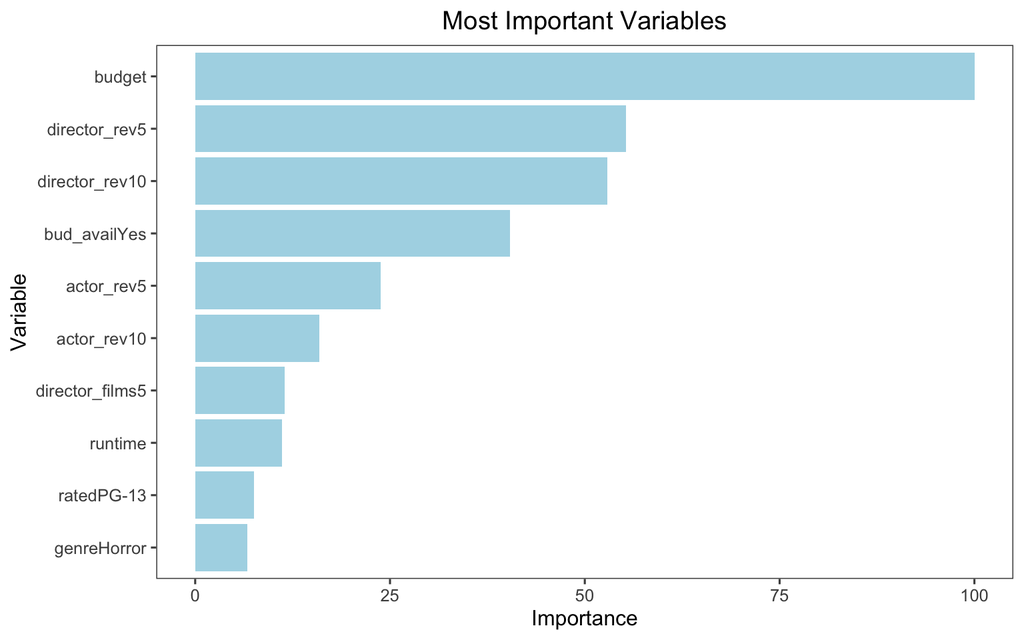

```r
plotImp(b1.import, 10)
```

### Random Forest

#### Full Model (V1)

```r
rf1.import <- varImp(rf1$model)

tableImp(rf1.import, 10)
```

|  | Overall |
| --- | --- |
| budget | 100.000000 |
| bud_availYes | 24.226549 |
| director_rev10 | 14.872920 |
| director_rev5 | 12.121446 |
| runtime | 10.781919 |
| actor_rev5 | 9.714001 |
| actor_rev10 | 9.310301 |
| actor_films10 | 5.324959 |
| actor_films5 | 4.569498 |
| director_films10 | 2.602546 |

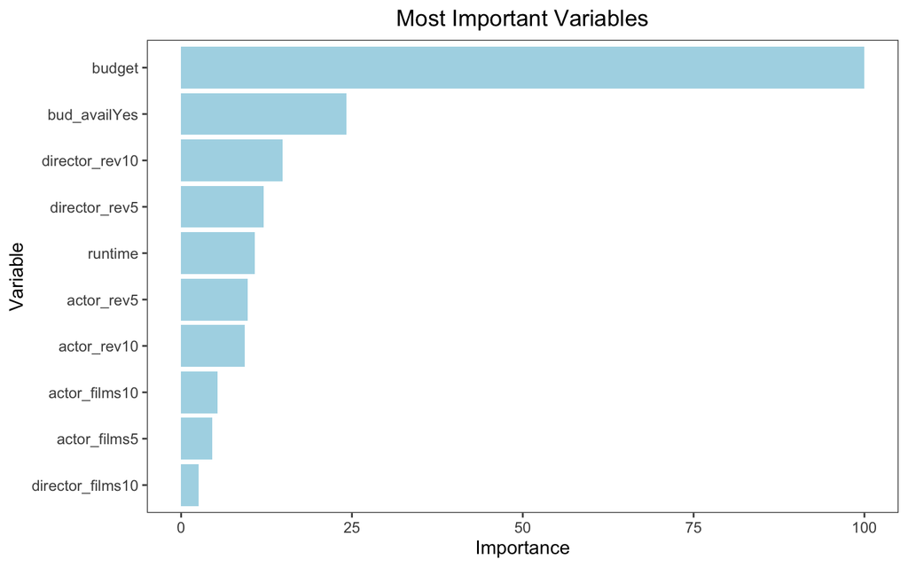

```r
plotImp(rf1.import, 10)
```

Tuning Parameter:

```r
rf1$model
```

```
## Random Forest
##
## 1378 samples
##   18 predictor
##
## No pre-processing
## Resampling: Cross-Validated (10 fold)
## Summary of sample sizes: 1240, 1239, 1240, 1240, 1240, 1241, ...
## Resampling results across tuning parameters:
##
##   mtry  RMSE      Rsquared   MAE
##    2    1.089755  0.6019913  0.8554087
##   21    1.011198  0.6250762  0.8035619
##   40    1.017215  0.6203623  0.8064708
##
## RMSE was used to select the optimal model using the smallest value.
## The final value used for the model was mtry = 21.
```

```r
rf2.import <- varImp(rf2$model)

tableImp(rf2.import, 10)
```

|  | Overall |
| --- | --- |
| budget | 100.000000 |
| bud_availYes | 24.583393 |
| director_rev10 | 14.534784 |
| director_rev5 | 12.811826 |
| runtime | 11.007748 |
| actor_rev5 | 10.115440 |
| actor_rev10 | 9.865975 |
| actor_films10 | 5.168749 |
| actor_films5 | 4.399251 |
| director_films10 | 2.694230 |

#### Best Model

```r
rf4.import <- varImp(rf4$model)
```

```r
tableImp(rf4.import, 10)
```

|  | Overall |
| --- | --- |
| budget | 100.000000 |
| bud_availYes | 25.623682 |
| director_rev10 | 20.453446 |
| actor_rev10 | 14.125389 |
| runtime | 13.432925 |
| actor_films10 | 8.610988 |
| director_films10 | 5.036964 |
| ratedR | 2.496025 |
| genreHorror | 2.403049 |
| countryUnited States | 2.153712 |

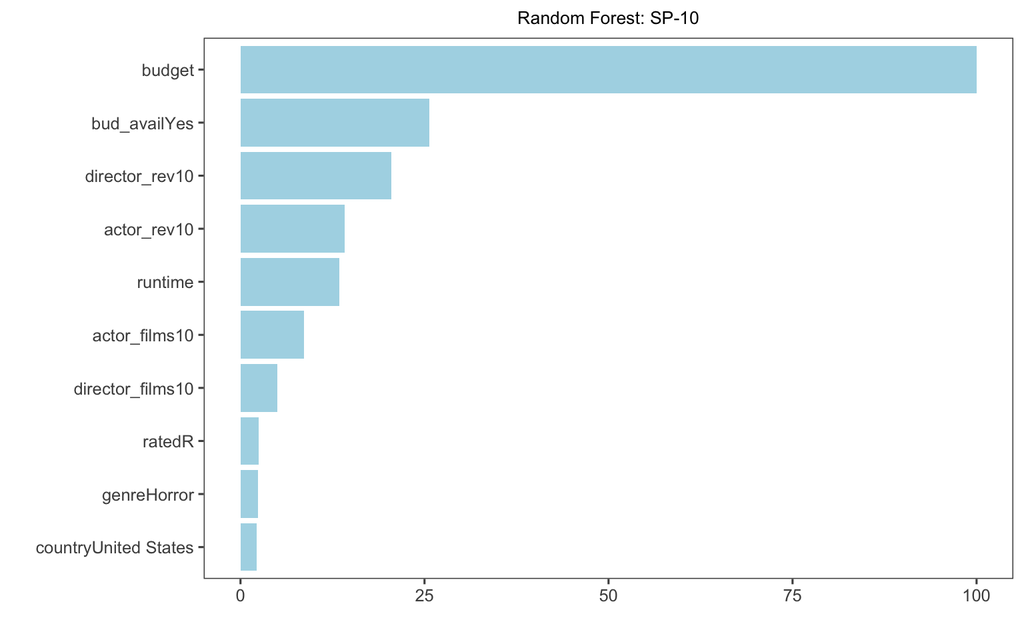

```r
plotImp(rf4.import, 10, title="Random Forest: SP-10")
```

### XGBoost

#### Full Model

```r
xgb1.import <- varImp(xgb1$model)

tableImp(xgb1.import, 10)
```

|  | Overall |
| --- | --- |
| budget | 100.000000 |
| bud_availYes | 31.750788 |
| director_rev5 | 8.726736 |
| director_rev10 | 8.228347 |
| genreHorror | 3.201705 |
| runtime | 2.295859 |
| actor_rev10 | 2.264511 |
| `countryUnited States` | 1.971501 |
| actor_rev5 | 1.970460 |
| ratedR | 1.961712 |

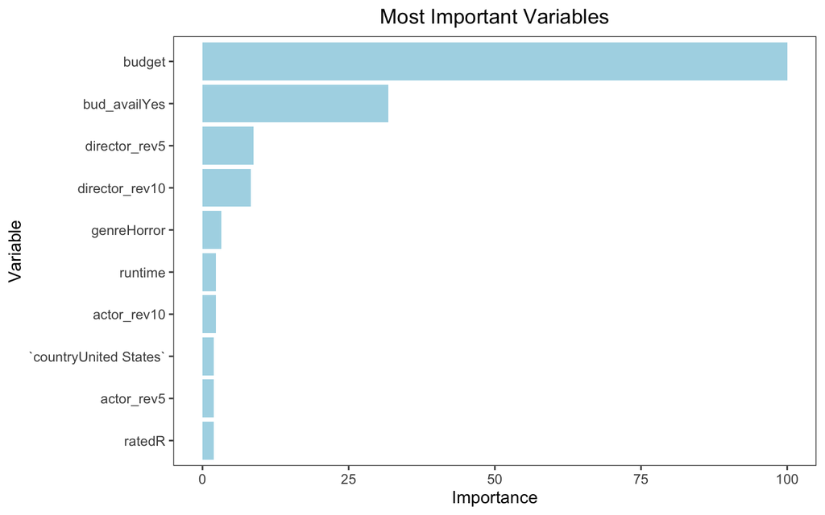

```r
plotImp(xgb1.import, 10)
```

### Cubist

#### Full Model

```r
cube1.import <- varImp(cube1$model)

tableImp(cube1.import, 10)
```

|  | Overall |
| --- | --- |
| budget | 100.00000 |
| ratedR | 53.33333 |
| director_films5 | 46.00000 |
| actor_films5 | 43.33333 |
| ratedPG-13 | 41.33333 |
| bud_availYes | 40.66667 |
| States | 38.00000 |
| runtime | 35.33333 |
| genreHorror | 34.66667 |
| ratedPG | 34.66667 |

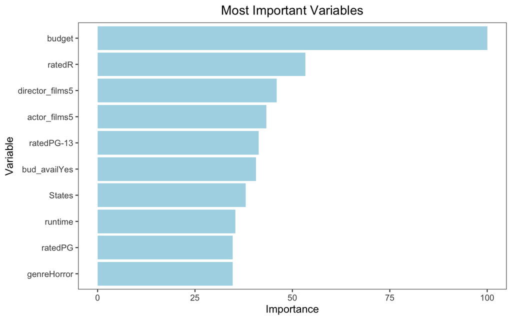

```r
plotImp(cube1.import, 10)
```

## Side-by-Side

### Full Model

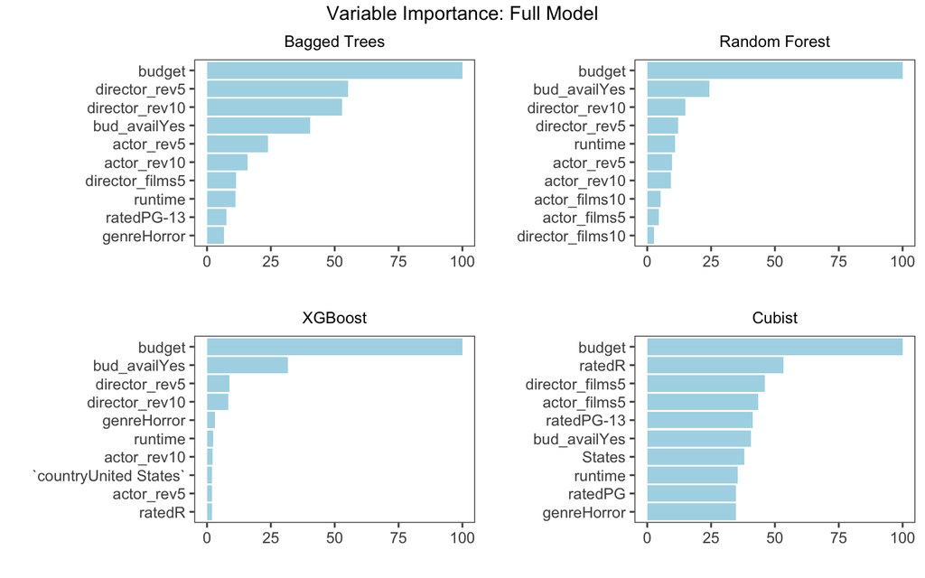

```r
f.v1.b <- plotImp(b1.import, 10, title="Bagged Trees")
f.v1.r <- plotImp(rf1.import, 10, title="Random Forest")
f.v1.x <- plotImp(xgb1.import, 10, title="XGBoost")
f.v1.c <- plotImp(cube1.import, 10, title="Cubist")

ggarrange(f.v1.b,
          f.v1.r,
          f.v1.x,
          f.v1.c,
          ncol=2, top="Variable Importance: Full Model")
```